# TFM_final

Eduardo Rivero Falcón

25/11/2020

# 1.- CARGA Y ANÁLISIS EXPLORATORIO INICIAL (EDA)

## Carga de datos.

```r
# librerías necesarias
library(ggplot2)
library(dplyr)

# carga y resumen
dfHD <- read.csv('./data/health_determ_EU_v0.csv')

str(dfHD)
```

```
## 'data.frame':    310 obs. of  26 variables:
##  $ GEO                                : Factor w/ 31 levels "Austria","Belgium",..: 2 2 2 2 2 2 2 2 2 2 ...
##  $ SEX                                : Factor w/ 2 levels "Females","Males": 2 2 2 2 2 1 1 1 1 1 ...
##  $ AGE                                : Factor w/ 5 levels "65 years or over",..: 2 3 4 5 1 2 3 4 5 1 ...
##  $ BMI_Underweight                    : num  11.9 2.4 0.3 0.4 0.6 13.2 7.7 2.5 2.4 2.7 ...
##  $ BMI_Normal                         : num  69.4 56.5 45.6 33.8 33.7 71.2 55.4 62.1 51 42.8 ...
##  $ BMI_Overweight                     : num  18.7 41 54.1 65.8 65.6 15.6 36.9 35.4 46.6 54.5 ...
##  $ Physical_activity                  : num  25.2 11.5 7.7 5.5 42 16.3 8.8 5.8 3.9 42 ...
##  $ DailyFyV_0.portions                : num  25.4 26.3 19.7 18.3 11.8 25.2 20.1 11.8 9.5 9.6 ...
##  $ DailyFyV_From.1.to.4.portions      : num  64.6 65.5 69.3 70.1 76 68.4 68.4 73.9 73.6 74.9 ...
##  $ DailyFyV_5.portions.or.more        : num  10 8.2 11 11.6 12.2 6.5 11.5 14.2 16.9 15.5 ...
##  $ smoking_Non.smoker                 : num  78.9 66.7 67.1 72.3 84.8 77.5 80.2 75.6 74.8 92.2 ...
##  $ smoking_Daily.smoker               : num  15.4 26.2 26.9 23.8 12.9 19.1 12.5 20.2 21.9 6.9 ...
##  $ smoking_Occasional.smoker          : num  5.7 7.1 6 3.9 2.3 3.4 7.3 4.2 3.3 0.9 ...
##  $ Frequent_drink_pct                 : num  50.1 45.3 43.1 37.7 20.1 35.6 17.5 16.9 17.9 9.7 ...
##  $ social_support_Intermediate        : num  49.2 51.5 52.4 50 51.5 50.4 57.7 51.2 50.7 47.7 ...
##  $ social_support_Poor                : num  11.5 14.7 17.7 20.4 19.1 15.8 9.1 18.1 17.6 21.1 ...
##  $ social_support_Strong              : num  39.2 33.8 29.8 29.6 29.3 33.8 33.1 30.7 31.6 31.2 ...
##  $ Chron_ill_pct                      : num  9.2 12.4 18.4 28 38.2 12.5 12.6 20.1 31.2 42.5 ...
##  $ Sev_body_pain_Mild.or.very.mild    : num  18.4 22.9 21.5 26 26.2 20.1 24.2 27.1 23.2 30.4 ...
##  $ Sev_body_pain_Severe.or.very.severe: num  1.7 4.4 8 10.2 9.7 6.9 9.1 8.7 15.8 17.8 ...
##  $ Sev_body_pain_Moderate             : num  7.4 9.8 13.2 12.7 18.6 7.9 13 18.1 19 22.7 ...
##  $ Sev_body_pain_None                 : num  72.5 62.9 57.3 51 45.4 65.1 53.7 46.1 41.9 29.1 ...
##  $ Health_Expend_._GDP                : num  10.4 10.4 10.4 10.4 10.4 ...
##  $ presc_med_use_pct                  : num  22.3 27.1 37.6 64 88.1 42.9 47.8 52.7 71.3 90.4 ...
##  $ non_presc_med_use_pct              : num  13.4 17.2 18.1 17 16.2 15.2 27.4 20.5 22.8 18.8 ...
##  $ SPH_G_or_VG_pct                    : num  94.8 89.4 83.8 74.5 53.3 91.7 88.8 79.8 70.1 50.4 ...
```

Observamos después de la carga que los tipos de variables se corresponden.

```r
# Estadísticas de valores nulos
colSums(is.na(dfHD))
```

```
##                                 GEO                                 SEX
##                                   0                                   0
##                                 AGE                     BMI_Underweight
##                                   0                                   0
##                          BMI_Normal                      BMI_Overweight
##                                   0                                   0
##                   Physical_activity                 DailyFyV_0.portions
##                                   0                                   0
##       DailyFyV_From.1.to.4.portions         DailyFyV_5.portions.or.more
##                                   0                                   0
##                  smoking_Non.smoker                smoking_Daily.smoker
##                                   0                                   0
##           smoking_Occasional.smoker                  Frequent_drink_pct
##                                   0                                   0
##         social_support_Intermediate                 social_support_Poor
##                                   0                                   0
##               social_support_Strong                       Chron_ill_pct
##                                   0                                   0
##     Sev_body_pain_Mild.or.very.mild Sev_body_pain_Severe.or.very.severe
##                                   0                                   0
##              Sev_body_pain_Moderate                  Sev_body_pain_None
##                                   0                                   0
##                 Health_Expend_._GDP                   presc_med_use_pct
##                                   0                                   0
##               non_presc_med_use_pct                     SPH_G_or_VG_pct
##                                   0                                   0
```

```r
summary(dfHD)
```

```
##        GEO           SEX                       AGE     BMI_Underweight
##  Austria : 10   Females:155   65 years or over   :62   Min.   : 0.000
##  Belgium : 10   Males  :155   From 15 to 24 years:62   1st Qu.: 0.600
##  Bulgaria: 10                 From 25 to 34 years:62   Median : 1.500
##  Croatia : 10                 From 35 to 44 years:62   Mean   : 3.217
##  Cyprus  : 10                 From 45 to 64 years:62   3rd Qu.: 4.475
##  Czechia : 10                                          Max.   :18.500
##  (Other) :250
##    BMI_Normal    BMI_Overweight  Physical_activity DailyFyV_0.portions
##  Min.   :18.80   Min.   : 9.20   Min.   : 0.000    Min.   : 9.50
##  1st Qu.:34.40   1st Qu.:29.35   1st Qu.: 4.225    1st Qu.:26.93
##  Median :48.10   Median :50.30   Median :11.350    Median :36.75
##  Mean   :49.02   Mean   :47.76   Mean   :14.880    Mean   :37.04
##  3rd Qu.:64.78   3rd Qu.:64.67   3rd Qu.:22.300    3rd Qu.:45.88
##  Max.   :82.30   Max.   :81.10   Max.   :64.200    Max.   :69.40
##
##  DailyFyV_From.1.to.4.portions DailyFyV_5.portions.or.more
##  Min.   :19.70                 Min.   : 2.20
##  1st Qu.:40.10                 1st Qu.: 6.70
##  Median :49.90                 Median :11.05
##  Mean   :50.30                 Mean   :12.66
##  3rd Qu.:60.38                 3rd Qu.:16.27
##  Max.   :82.60                 Max.   :41.10
##
##  smoking_Non.smoker smoking_Daily.smoker smoking_Occasional.smoker
##  Min.   :41.90      Min.   : 1.10        Min.   : 0.10
##  1st Qu.:67.30      1st Qu.:11.93        1st Qu.: 3.30
##  Median :75.90      Median :17.60        Median : 5.20
##  Mean   :74.61      Mean   :19.77        Mean   : 5.62
##  3rd Qu.:82.17      3rd Qu.:26.18        3rd Qu.: 7.45
##  Max.   :98.30      Max.   :51.20        Max.   :15.20
##
##  Frequent_drink_pct social_support_Intermediate social_support_Poor
##  Min.   : 0.10      Min.   :28.90               Min.   : 1.60
##  1st Qu.: 7.70      1st Qu.:45.92               1st Qu.: 9.10
##  Median :15.95      Median :52.20               Median :15.00
##  Mean   :20.22      Mean   :50.23               Mean   :14.75
##  3rd Qu.:30.98      3rd Qu.:55.77               3rd Qu.:18.98
##  Max.   :67.50      Max.   :67.00               Max.   :34.80
##
```

[output cut: 17 more lines]

```
##  Min.   : 8.30      Min.   : 4.350      Min.   : 1.70
##  1st Qu.:36.83      1st Qu.: 6.700      1st Qu.:22.32
##  Median :49.90      Median : 8.500      Median :35.15
##  Mean   :50.75      Mean   : 8.269      Mean   :42.50
##  3rd Qu.:64.65      3rd Qu.: 9.960      3rd Qu.:60.33
##  Max.   :92.20      Max.   :11.580      Max.   :92.80
##
##  non_presc_med_use_pct SPH_G_or_VG_pct
##  Min.   : 6.70         Min.   : 3.00
##  1st Qu.:26.60         1st Qu.:59.50
##  Median :36.25         Median :80.10
##  Mean   :38.68         Mean   :71.44
##  3rd Qu.:48.85         3rd Qu.:89.67
##  Max.   :90.60         Max.   :98.80
##
```

Sin nulos, valores de las categóricas (dimensiones) correctas, rango valores de las numéricas compatible con sus unidades (porcentaje).

## EDA: Análisis unidimensional

```r
# librerías para 'bloques'rejilla' de gráficos (grid)
library(ggplot2)
library(grid)
library(gridExtra)
```

### Variables categóricas (dimensiones)

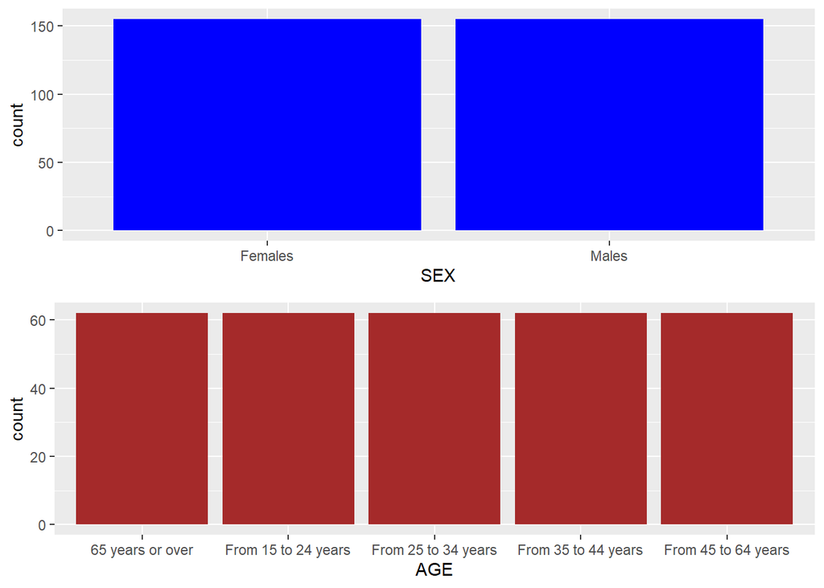

```r
grid.newpage()

plot.SEX <- ggplot(data = dfHD) + geom_bar(mapping = aes(x = SEX), fill='blue')

plot.AGE <- ggplot(data = dfHD) + geom_bar(mapping = aes(x = AGE),fill='brown')

grid.arrange(plot.SEX,plot.AGE, nrow=2)
```

El esperado dada la naturaleza (dimensiones) de estas variables. Recordar que por cada país tenemos las mismas combinaciones posibles de los dos géneros y los 5 grupos de edad, luego todas las categorías de cada dimensión tendrán el mismo número de observaciones correspondientes.

### Variable BMI

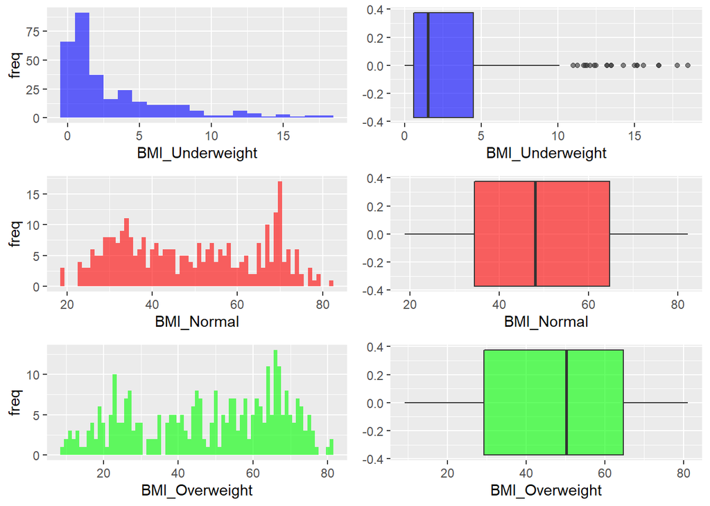

```r
# crear rejilla
grid.newpage()


# bloques rejilla
plot.bmiund.hist <- ggplot(data = dfHD) +
  geom_histogram(mapping = aes(x = BMI_Underweight), fill='blue',alpha=0.6,binwidth = 1) +
  labs(y='freq')
plot.bmiund.box <- ggplot(data = dfHD) +
  geom_boxplot(mapping = aes(y = BMI_Underweight), fill='blue',alpha=0.6) + coord_flip()


plot.bminorm.hist <- ggplot(data = dfHD) +
  geom_histogram(mapping = aes(x = BMI_Normal), fill='red',alpha=0.6,binwidth = 1) +
  labs(y='freq')
plot.bminorm.box <- ggplot(data = dfHD) +
  geom_boxplot(mapping = aes(y = BMI_Normal), fill='red',alpha=0.6) + coord_flip()


plot.bmiover.hist <- ggplot(data = dfHD) +
  geom_histogram(mapping = aes(x = BMI_Overweight), fill='green',alpha=0.6,binwidth = 1) +
  labs(y='freq')
plot.bmiover.box <- ggplot(data = dfHD) +
  geom_boxplot(mapping = aes(y = BMI_Overweight), fill='green',alpha=0.6) + coord_flip()


# mostrar rejilla
grid.arrange(plot.bmiund.hist,plot.bmiund.box,plot.bminorm.hist,plot.bminorm.box,
plot.bmiover.hist,plot.bmiover.box,nrow=3,ncol=2)
```

Valores bajos en la categoría ‘Underweight’, con presencia de atípicos por encima del 10% que pueden entrar dentro de la lógica en países del entorno europeo.Valores distribución de sobrepeso (con sesgo a la derecha) algo superiores a los del peso normal, alcanzando valores del 80%

```r
# resumen numérico boxplot, del que observamos outliers
boxplot.stats(x=dfHD$BMI_Underweight)
```

```
## $stats
## [1]  0.0  0.6  1.5  4.5 10.1
##
## $n
## [1] 310
##
## $conf
## [1] 1.150022 1.849978
##
## $out
##  [1] 11.9 13.2 15.2 11.3 11.8 11.7 12.5 13.5 11.0 16.6 12.4 18.5 15.0 15.2
## [15] 13.2 16.6 12.1 15.6 13.5 14.3 17.8
```

Como hemos comentado los valores atípicos (outliers) que nos encontramos para ‘Underweight’ no parecen fruto de error sino de valores posibles de la variable para el entorno europeo.

Para el posterior análisis (odds-ratio de la regresión logística) donde estos outliers pueden constituir ruido que altere los resultados del análisis, decidimos truncar los valores que excedan en un 20% del valor típico extremo (en este caso el máximo) a ese 20% más del valor máximo, conservando así esos valores y su tendencia (valores altos/bajos). Se prefierre esta alternativa a eliminarlos (mejor que eliminarlos) dado el relativo bajo número de observaciones o realizar algún tipo de imputación que altere dicha tendencia.

```r
# estado anterior
summary(dfHD$BMI_Underweight)
```

```
##    Min. 1st Qu.  Median    Mean 3rd Qu.    Max.
##   0.000   0.600   1.500   3.217   4.475  18.500
```

```r
#corrección
maximo <- 1.2*boxplot.stats(x=dfHD$BMI_Underweight)$stats[5]

dfHD$BMI_Underweight[dfHD$BMI_Underweight > maximo] <- maximo


# estado posterior
summary(dfHD$BMI_Underweight)
```

```
##    Min. 1st Qu.  Median    Mean 3rd Qu.    Max.
##   0.000   0.600   1.500   3.084   4.475  12.120
```

### Variables ‘smoke’.

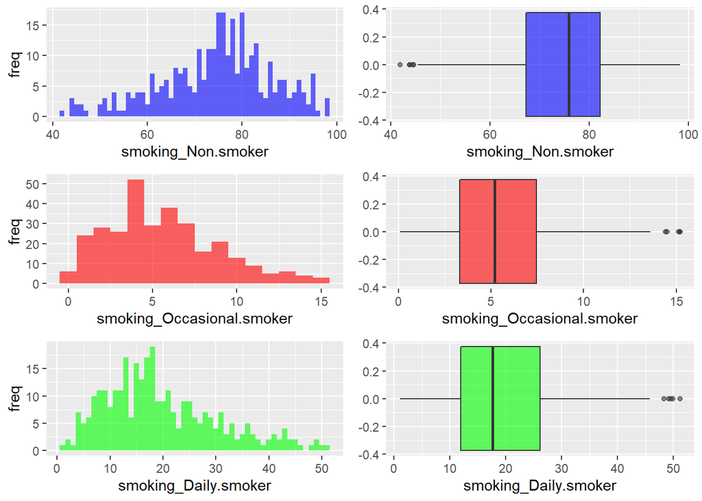

```r
grid.newpage()


plot.smkno.hist <- ggplot(data = dfHD) +
  geom_histogram(mapping = aes(x = smoking_Non.smoker), fill='blue',alpha=0.6,binwidth = 1) +
  labs(y='freq')
plot.smkno.box <- ggplot(data = dfHD) +
  geom_boxplot(mapping = aes(y = smoking_Non.smoker), fill='blue',alpha=0.6) + coord_flip()


plot.smkoc.hist <- ggplot(data = dfHD) +
  geom_histogram(mapping = aes(x = smoking_Occasional.smoker), fill='red',alpha=0.6,binwidth = 1) +
  labs(y='freq')
plot.smkoc.box <- ggplot(data = dfHD) +
  geom_boxplot(mapping = aes(y = smoking_Occasional.smoker), fill='red',alpha=0.6) + coord_flip()


plot.smkday.hist <- ggplot(data = dfHD) +
  geom_histogram(mapping = aes(x = smoking_Daily.smoker), fill='green',alpha=0.6,binwidth = 1) +
  labs(y='freq')
plot.smkday.box <- ggplot(data = dfHD) +
  geom_boxplot(mapping = aes(y = smoking_Daily.smoker), fill='green',alpha=0.6) + coord_flip()



grid.arrange(plot.smkno.hist,plot.smkno.box,plot.smkoc.hist,plot.smkoc.box,
plot.smkday.hist,plot.smkday.box,nrow=3,ncol=2)
```

Valores altos de porcentajes de no fumadores (primer quartil alcanza casi el 70%) frente a valores más pequeños de ocasionales y diarios, si bien en estos últimos se alcanzan valores que alcanzan el 50%. Valores atípicos en bajo número presentes en todas las categorías, no muy distanciados. De nuevo no parecen fruto de errores.

Por lo tanto aplicaremos el mismo tratamiento de truncar aquellos valores si existiesen que superen en un 20% el valor máximo tìpico.

**NOTA:**Por lo general y a partir de este momento realizaremos siempre esta corrección de outliers, a menos que observemos en los mismos algún posible origen de error y no puedan ser compatibles con una distribución de la población en el ámbito de nuestro estudio.

```r
#  estado anterior
summary(dfHD$smoking_Non.smoker)
```

```
##    Min. 1st Qu.  Median    Mean 3rd Qu.    Max.
##   41.90   67.30   75.90   74.61   82.17   98.30
```

```r
# corrección 'non smoker'
minimo <- 0.8*boxplot.stats(x=dfHD$smoking_Non.smoker)$stats[1]

dfHD$smoking_Non.smoker[dfHD$smoking_Non.smoker < minimo] <- minimo

# estado posterior
summary(dfHD$smoking_Non.smoker)
```

```
##    Min. 1st Qu.  Median    Mean 3rd Qu.    Max.
##   41.90   67.30   75.90   74.61   82.17   98.30
```

```r
# ambos outliers derecha
colsmk <- c("smoking_Occasional.smoker","smoking_Daily.smoker")

for (col in colsmk){

  # estado anterior
  print(summary(dfHD[,col]))

  # correccion
  maximo <- 1.2*boxplot.stats(x=dfHD[,col])$stats[5]
  dfHD[,col][dfHD[,col] > maximo] <- maximo

  # estado posterior
  print(summary(dfHD[,col]))
  print("----------------------------")


}
```

```
##    Min. 1st Qu.  Median    Mean 3rd Qu.    Max.
##    0.10    3.30    5.20    5.62    7.45   15.20
##    Min. 1st Qu.  Median    Mean 3rd Qu.    Max.
##    0.10    3.30    5.20    5.62    7.45   15.20
## [1] "----------------------------"
##    Min. 1st Qu.  Median    Mean 3rd Qu.    Max.
##    1.10   11.93   17.60   19.77   26.18   51.20
##    Min. 1st Qu.  Median    Mean 3rd Qu.    Max.
##    1.10   11.93   17.60   19.77   26.18   51.20
## [1] "----------------------------"
```

### Variables ‘Physical_activity’ y ‘Frequent_drink_pct’.

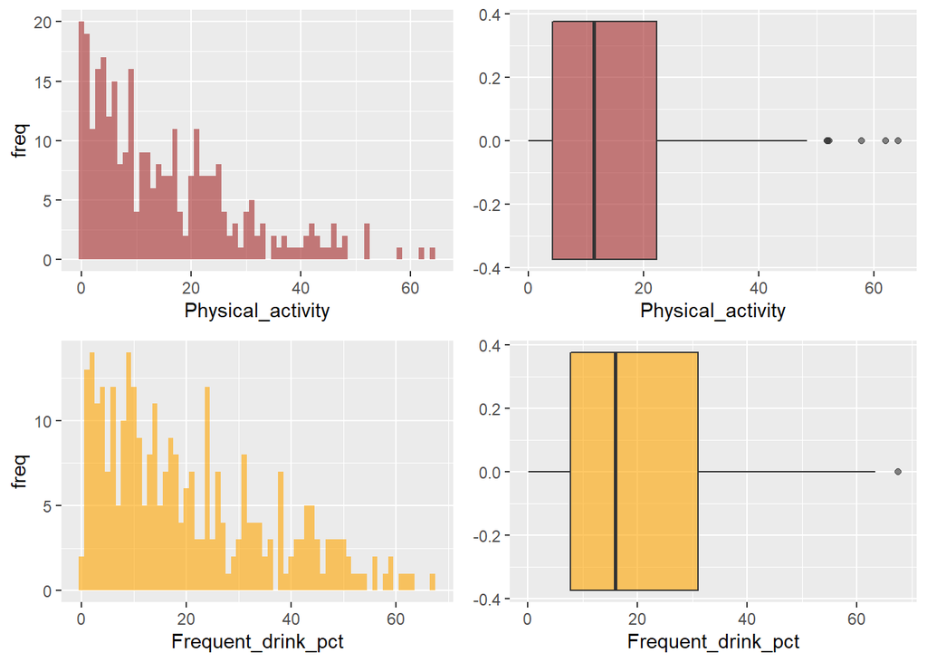

```r
grid.newpage()


plot.physact.hist <- ggplot(data = dfHD) +
  geom_histogram(mapping = aes(x = Physical_activity), fill='brown',alpha=0.6,binwidth = 1) +
  labs(y='freq')
plot.physact.box <- ggplot(data = dfHD) +
  geom_boxplot(mapping = aes(y = Physical_activity), fill='brown',alpha=0.6) + coord_flip()


plot.freqdrink.hist <- ggplot(data = dfHD) +
  geom_histogram(mapping = aes(x = Frequent_drink_pct), fill='orange',alpha=0.6,binwidth = 1) +
  labs(y='freq')
plot.freqdrink.box <- ggplot(data = dfHD) +
  geom_boxplot(mapping = aes(y = Frequent_drink_pct), fill='orange',alpha=0.6) + coord_flip()



grid.arrange(plot.physact.hist,plot.physact.box,plot.freqdrink.hist,plot.freqdrink.box,
nrow=2,ncol=2)
```

Valores de la Actividad Física que alcanzan hasta poco más del 60% (tercer quantil algo más de 20) Para los Bebedores Frecuentes se alcanza casi el 65% (tercer quartil 30 aprox.). Presencia de valores atípicos a la derecha en ambos, con mayor número y separación para el primero y un solo valor no muy alejado en el segundo.

Se realiza el truncamiento de extremos como en anteriores variables.

```r
# ambos outliers a la derecha
colsvar <- c("Physical_activity","Frequent_drink_pct")

for (col in colsvar){

  # estado anterior
  print(summary(dfHD[,col]))

  # correccion
  maximo <- 1.2*boxplot.stats(x=dfHD[,col])$stats[5]
  dfHD[,col][dfHD[,col] > maximo] <- maximo

  # estado posterior
  print(summary(dfHD[,col]))
  print("----------------------------")


}
```

```
##    Min. 1st Qu.  Median    Mean 3rd Qu.    Max.
##   0.000   4.225  11.350  14.880  22.300  64.200
##    Min. 1st Qu.  Median    Mean 3rd Qu.    Max.
##   0.000   4.225  11.350  14.848  22.300  58.080
## [1] "----------------------------"
##    Min. 1st Qu.  Median    Mean 3rd Qu.    Max.
##    0.10    7.70   15.95   20.22   30.98   67.50
##    Min. 1st Qu.  Median    Mean 3rd Qu.    Max.
##    0.10    7.70   15.95   20.22   30.98   67.50
## [1] "----------------------------"
```

### Variables Consumo diario Frutas y Verduras.

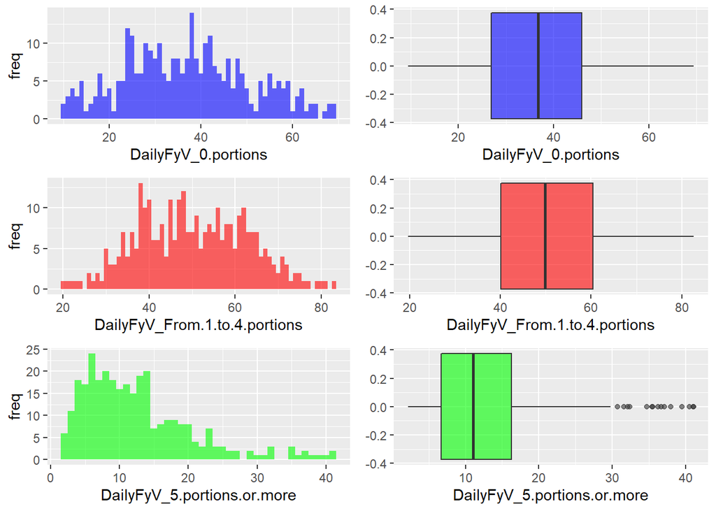

```r
grid.newpage()


plot.fyv0.hist <- ggplot(data = dfHD) +
  geom_histogram(mapping = aes(x = DailyFyV_0.portions), fill='blue',alpha=0.6,binwidth = 1) +
  labs(y='freq')
plot.fyv0.box <- ggplot(data = dfHD) +
  geom_boxplot(mapping = aes(y = DailyFyV_0.portions), fill='blue',alpha=0.6) + coord_flip()


plot.fyv1_4.hist <- ggplot(data = dfHD) +
  geom_histogram(mapping = aes(x = DailyFyV_From.1.to.4.portions), fill='red',alpha=0.6,binwidth = 1) +
  labs(y='freq')
plot.fyv1_4.box <- ggplot(data = dfHD) +
  geom_boxplot(mapping = aes(y = DailyFyV_From.1.to.4.portions), fill='red',alpha=0.6) + coord_flip()


plot.fyv5.hist <- ggplot(data = dfHD) +
  geom_histogram(mapping = aes(x = DailyFyV_5.portions.or.more), fill='green',alpha=0.6,binwidth = 1) +
  labs(y='freq')
plot.fyv5.box <- ggplot(data = dfHD) +
  geom_boxplot(mapping = aes(y = DailyFyV_5.portions.or.more), fill='green',alpha=0.6) + coord_flip()



grid.arrange(plot.fyv0.hist,plot.fyv0.box,plot.fyv1_4.hist,plot.fyv1_4.box,
plot.fyv5.hist,plot.fyv5.box,nrow=3,ncol=2)
```

Se observan porcentajes considerables de la población que no consumen diariamente frutas y verduras (1er Q por encima de 25, 2do Q 45 aprox.), llegando a casi 70 % en algunos casos. Valores considerables entre los del porcentaje de población que la consume en menor cantidad de la recomendada (1er Q 40, 2do Q 60), hasta poco más de 80 %. Sin atípicos en ambos.

A resaltar valores bajos por lo general para el consumo recomendado de al menos 5 piezas diarias (1er Q 7 aprox, 2do Q algo más de 15), con valores atípicos que llegan ha sobrepasar ligeremante 40.

```r
# estado anterior
print(summary(dfHD$DailyFyV_5.portions.or.more))
```

```
##    Min. 1st Qu.  Median    Mean 3rd Qu.    Max.
##    2.20    6.70   11.05   12.66   16.27   41.10
```

```r
# correccion
maximo <- 1.2*boxplot.stats(x=dfHD$DailyFyV_5.portions.or.more)$stats[5]
dfHD$DailyFyV_5.portions.or.more[dfHD$DailyFyV_5.portions.or.more > maximo] <- maximo

# estado posterior
print(summary(dfHD$DailyFyV_5.portions.or.more))
```

```
##    Min. 1st Qu.  Median    Mean 3rd Qu.    Max.
##    2.20    6.70   11.05   12.61   16.27   36.84
```

### Variables Social Support

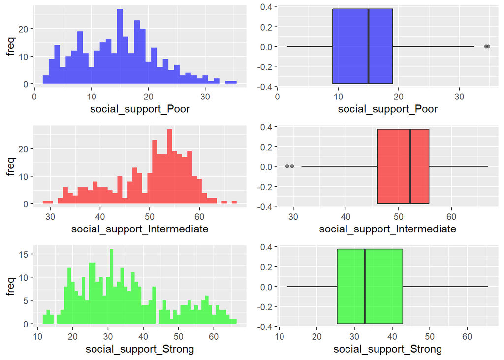

```r
grid.newpage()


plot.SSptPoor.hist <- ggplot(data = dfHD) +
  geom_histogram(mapping = aes(x = social_support_Poor), fill='blue',alpha=0.6,binwidth = 1) +
  labs(y='freq')
plot.SSptPoor.box <- ggplot(data = dfHD) +
  geom_boxplot(mapping = aes(y = social_support_Poor), fill='blue',alpha=0.6) + coord_flip()


plot.SSptInterm.hist <- ggplot(data = dfHD) +
  geom_histogram(mapping = aes(x = social_support_Intermediate), fill='red',alpha=0.6,binwidth = 1) +
  labs(y='freq')
plot.SSptInterm.box <- ggplot(data = dfHD) +
  geom_boxplot(mapping = aes(y = social_support_Intermediate), fill='red',alpha=0.6) + coord_flip()


plot.SSptStrong.hist <- ggplot(data = dfHD) +
  geom_histogram(mapping = aes(x = social_support_Strong), fill='green',alpha=0.6,binwidth = 1) +
  labs(y='freq')
plot.SSptStrong.box <- ggplot(data = dfHD) +
  geom_boxplot(mapping = aes(y = social_support_Strong), fill='green',alpha=0.6) + coord_flip()



grid.arrange(plot.SSptPoor.hist,plot.SSptPoor.box,plot.SSptInterm.hist,plot.SSptInterm.box,
plot.SSptStrong.hist,plot.SSptStrong.box,nrow=3,ncol=2)
```

Entre las variables relativas al Soporte Social destacar que los valores para la categoría ‘Pobre’ son menores a los otros dos, siendo el de ‘Intermedio’ algo superiores al de ‘Fuerte’. Presencia de valores extremos en los dos primeros niveles comentados, escasos y no muy alejados en cualquier caso.

```r
# estado anterior 'Poor'
summary(dfHD$social_support_Poor)
```

```
##    Min. 1st Qu.  Median    Mean 3rd Qu.    Max.
##    1.60    9.10   15.00   14.75   18.98   34.80
```

```r
# correccion
maximo <- 1.2*boxplot.stats(x=dfHD$social_support_Poor)$stats[5]

dfHD$social_support_Poor[dfHD$social_support_Poor > maximo] <- maximo


# estado posterior 'Poor'
summary(dfHD$social_support_Poor)
```

```
##    Min. 1st Qu.  Median    Mean 3rd Qu.    Max.
##    1.60    9.10   15.00   14.75   18.98   34.80
```

```r
# estado anterior 'Intermediate'
summary(dfHD$social_support_Intermediate)
```

```
##    Min. 1st Qu.  Median    Mean 3rd Qu.    Max.
##   28.90   45.92   52.20   50.23   55.77   67.00
```

```r
# correccion
minimo <- 0.8*boxplot.stats(x=dfHD$social_support_Intermediate)$stats[1]

dfHD$social_support_Intermediate[dfHD$social_support_Intermediate < minimo] <- minimo

# estado posterior 'Intermediate'
summary(dfHD$social_support_Intermediate)
```

```
##    Min. 1st Qu.  Median    Mean 3rd Qu.    Max.
##   28.90   45.92   52.20   50.23   55.77   67.00
```

### Variable Severidad dolor físico.

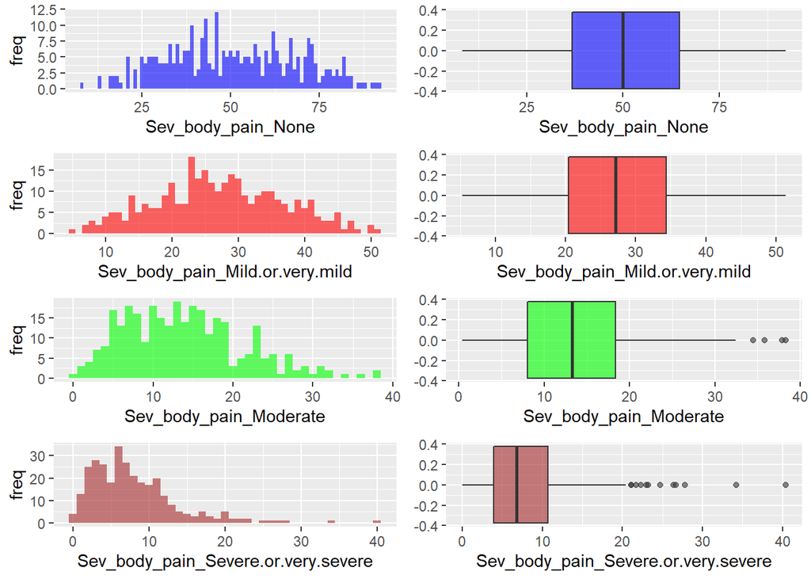

```r
grid.newpage()


plot.BdyPnNon.hist <- ggplot(data = dfHD) +
  geom_histogram(mapping = aes(x = Sev_body_pain_None), fill='blue',alpha=0.6,binwidth = 1) +
  labs(y='freq')
plot.BdyPnNon.box <- ggplot(data = dfHD) +
  geom_boxplot(mapping = aes(y = Sev_body_pain_None), fill='blue',alpha=0.6) + coord_flip()


plot.BdyPnMild.hist <- ggplot(data = dfHD) +
  geom_histogram(mapping = aes(x = Sev_body_pain_Mild.or.very.mild), fill='red',alpha=0.6,binwidth = 1) +
  labs(y='freq')
plot.BdyPnMild.box <- ggplot(data = dfHD) +
  geom_boxplot(mapping = aes(y = Sev_body_pain_Mild.or.very.mild), fill='red',alpha=0.6) + coord_flip()


plot.BdyPnMod.hist <- ggplot(data = dfHD) +
  geom_histogram(mapping = aes(x = Sev_body_pain_Moderate), fill='green',alpha=0.6,binwidth = 1) +
  labs(y='freq')
plot.BdyPnMod.box <- ggplot(data = dfHD) +
  geom_boxplot(mapping = aes(y = Sev_body_pain_Moderate), fill='green',alpha=0.6) + coord_flip()


plot.BdyPnSev.hist <- ggplot(data = dfHD) +
  geom_histogram(mapping = aes(x = Sev_body_pain_Severe.or.very.severe), fill='brown',alpha=0.6,binwidth = 1) +
  labs(y='freq')
plot.BdyPnSev.box <- ggplot(data = dfHD) +
  geom_boxplot(mapping = aes(y = Sev_body_pain_Severe.or.very.severe), fill='brown',alpha=0.6) + coord_flip()



grid.arrange(plot.BdyPnNon.hist,plot.BdyPnNon.box,plot.BdyPnMild.hist,plot.BdyPnMild.box,
plot.BdyPnMod.hist,plot.BdyPnMod.box,plot.BdyPnSev.hist,plot.BdyPnSev.box,nrow=4,ncol=2)
```

Entre los niveles de dolor, los mayores valores de porcentaje se encuentran en dolor leve o muy leve y ausencia de dolor físico, con medianas respectivas de 27 y 50 aprox., llegando a alcanzar valores alrededor de 50 y 90. Sin valores extremos ambas categorias.

Los porcentajes de nivel moderado son más bajos con mediana cercana a 15, alcanzando valores que sobrepasan 30 y con valores atípicos hasta cerca de los 40. Aun menor los porcentajes para el dolor severo y muy severo. El 3er Q apenas sobrepasa los 10 con valores hasta 20 y atípicos que concentrados la gran mayoría en menos de 30.

La distribución de los niveles de dolor parece la usual entre una población genérica.

```r
# ambos outliers a la derecha
colsvar <- c("Sev_body_pain_Moderate","Sev_body_pain_Severe.or.very.severe")

for (col in colsvar){

  # estado anterior
  print(summary(dfHD[,col]))

  # correccion
  maximo <- 1.2*boxplot.stats(x=dfHD[,col])$stats[5]
  dfHD[,col][dfHD[,col] > maximo] <- maximo


  # estado posterior
  print(summary(dfHD[,col]))
  print("----------------------------")


}
```

```
##    Min. 1st Qu.  Median    Mean 3rd Qu.    Max.
##    0.40    8.00   13.25   13.91   18.35   38.30
##    Min. 1st Qu.  Median    Mean 3rd Qu.    Max.
##    0.40    8.00   13.25   13.91   18.35   38.30
## [1] "----------------------------"
##    Min. 1st Qu.  Median    Mean 3rd Qu.    Max.
##   0.000   3.900   6.750   8.025  10.700  40.400
##    Min. 1st Qu.  Median    Mean 3rd Qu.    Max.
##   0.000   3.900   6.750   7.918  10.700  24.480
## [1] "----------------------------"
```

### Variables Tasa de enfermedad crónica y Gasto sanitario (% del PIB).

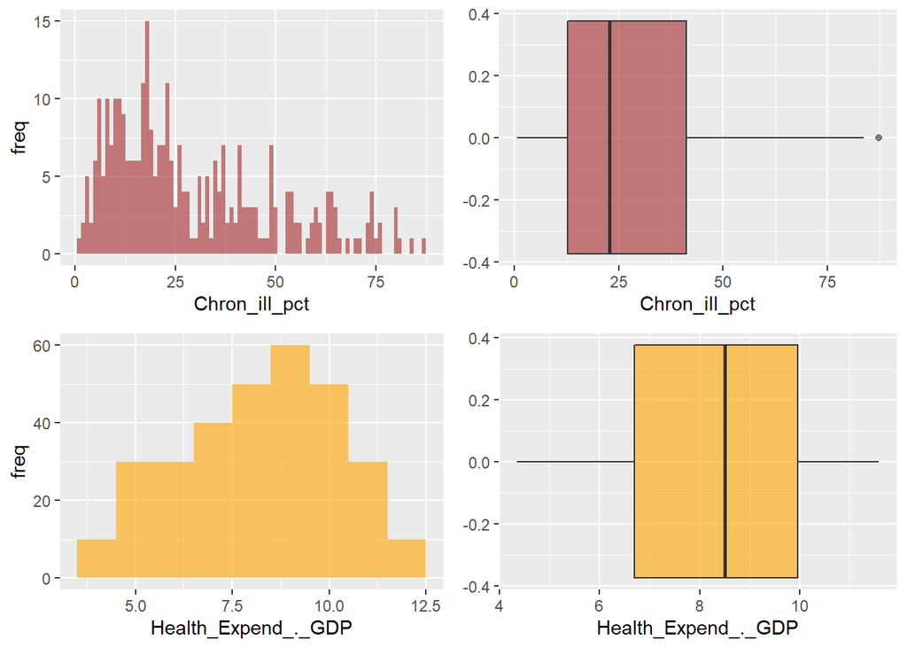

```r
grid.newpage()


plot.ChronIll.hist <- ggplot(data = dfHD) +
  geom_histogram(mapping = aes(x = Chron_ill_pct), fill='brown',alpha=0.6,binwidth = 1) +
  labs(y='freq')
plot.ChronIll.box <- ggplot(data = dfHD) +
  geom_boxplot(mapping = aes(y = Chron_ill_pct), fill='brown',alpha=0.6) + coord_flip()


plot.HlthExpend.hist <- ggplot(data = dfHD) +
  geom_histogram(mapping = aes(x = Health_Expend_._GDP), fill='orange',alpha=0.6,binwidth = 1) +
  labs(y='freq')
plot.HlthExpend.box <- ggplot(data = dfHD) +
  geom_boxplot(mapping = aes(y = Health_Expend_._GDP), fill='orange',alpha=0.6) + coord_flip()



grid.arrange(plot.ChronIll.hist,plot.ChronIll.box,plot.HlthExpend.hist,plot.HlthExpend.box,
nrow=2,ncol=2)
```

Nos encontramos con una tasa de enfermedad crónica con porcentajes extendidos. Con mediana de 25%, 1er Q de 12 y 3er Q de 40 aprox, los máximos alzanzan hasta 80 aprox. Presencia de un atípico testimonial.

En cuanto al gasto sanitario el histograma sin ‘picos’ locales ni generales se explica debido a que dicho valor no depende de los grupos de edad ni género, son el mismo para todos los grupos de un mismo país.Los valores se reparten desde poco más de 4 hasta el 11.5% del PIB aprox., con 1er Q de casi el 7% y 3er Q de 10. se percibe ligero sesgo a la derecha. Sin valores atípicos.

```r
# estado anterior
summary(dfHD$Chron_ill_pct)
```

```
##    Min. 1st Qu.  Median    Mean 3rd Qu.    Max.
##    0.60   12.65   22.75   28.81   41.25   87.30
```

```r
# correccion
maximo <- 1.2*boxplot.stats(x=dfHD$Chron_ill_pct)$stats[5]

dfHD$Chron_ill_pct[dfHD$Chron_ill_pct > maximo] <- maximo

# estado posterior
print("Despues:")
```

```
## [1] "Despues:"
```

```r
summary(dfHD$Chron_ill_pct)
```

```
##    Min. 1st Qu.  Median    Mean 3rd Qu.    Max.
##    0.60   12.65   22.75   28.81   41.25   87.30
```

### Variables Uso de Medicinas Prescritas y No Prescritas

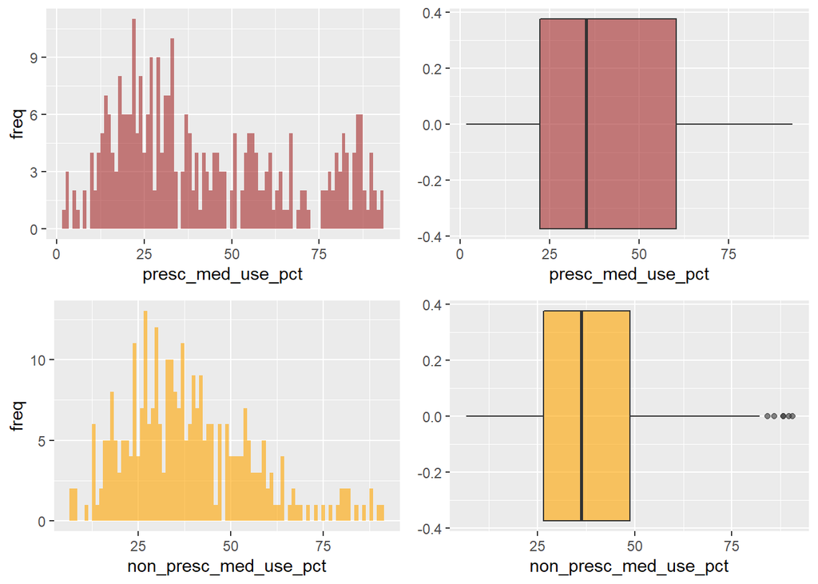

```r
grid.newpage()


plot.PrescrMed.hist <- ggplot(data = dfHD) +
  geom_histogram(mapping = aes(x = presc_med_use_pct), fill='brown',alpha=0.6,binwidth = 1) +
  labs(y='freq')
plot.PrescrMed.box <- ggplot(data = dfHD) +
  geom_boxplot(mapping = aes(y = presc_med_use_pct), fill='brown',alpha=0.6) + coord_flip()


plot.NonPrescrMed.hist <- ggplot(data = dfHD) +
  geom_histogram(mapping = aes(x = non_presc_med_use_pct), fill='orange',alpha=0.6,binwidth = 1) +
  labs(y='freq')
plot.NonPrescrMed.box <- ggplot(data = dfHD) +
  geom_boxplot(mapping = aes(y = non_presc_med_use_pct), fill='orange',alpha=0.6) + coord_flip()



grid.arrange(plot.PrescrMed.hist,plot.PrescrMed.box,plot.NonPrescrMed.hist,plot.NonPrescrMed.box,
nrow=2,ncol=2)
```

En cuanto al uso de medicinas prescritas y no prescritas se observan 1eros Qs y medianas semejantes (alrededor de 25 y de 37.5 respectivamente), si bien el rango intercuartílico es mayor para la primera. Ambas alcanzan en sus valores máximos cerca de 90, tratándose de valores atípicos en el caso de las no prescritas.

```r
# estado anterior
summary(dfHD$non_presc_med_use_pct)
```

```
##    Min. 1st Qu.  Median    Mean 3rd Qu.    Max.
##    6.70   26.60   36.25   38.68   48.85   90.60
```

```r
#correccion
maximo <- 1.2*boxplot.stats(x=dfHD$non_presc_med_use_pct)$stats[5]

dfHD$non_presc_med_use_pct[dfHD$non_presc_med_use_pct > maximo] <- maximo


# estado posterior
summary(dfHD$non_presc_med_use_pct)
```

```
##    Min. 1st Qu.  Median    Mean 3rd Qu.    Max.
##    6.70   26.60   36.25   38.68   48.85   90.60
```

### Variable objetivo: SPH Good or Very Good

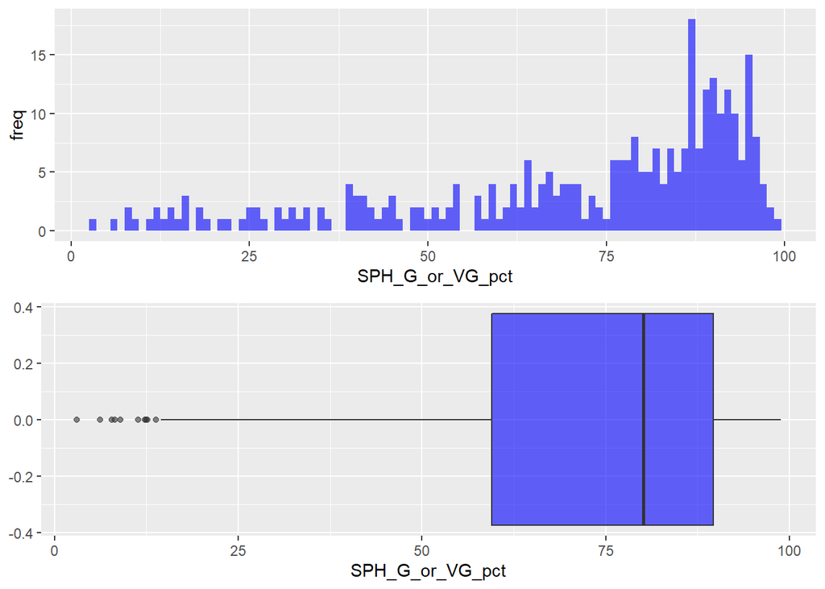

```r
grid.newpage()


plot.SPH.hist <- ggplot(data = dfHD) +
  geom_histogram(mapping = aes(x = SPH_G_or_VG_pct), fill='blue',alpha=0.6,binwidth = 1) +
  labs(y='freq')
plot.SPH.box <- ggplot(data = dfHD) +
  geom_boxplot(mapping = aes(y = SPH_G_or_VG_pct), fill='blue',alpha=0.6) + coord_flip()


grid.arrange(plot.SPH.hist,plot.SPH.box,nrow=2,ncol=1)
```

En primer lugar los diagramas muestran una distribución de valores por encima del 50% la gran mayoría, con 1er Q de 59.5 y mediana de 80.1 (media 71.4, del resumen estadístico inicial). Valores máximos llegan casi a al centena. Se observa por lo tanto una clara tendencia a valorar positivamente el estado de salud.

En el caso de la variable objetivo lo que nos ocupa es decidir el valor umbral (threshold) a la hora de convertir esta variable (porcentajes) en la dicotómica necesaria para el posterior análisis aplicando regresión logística, y para proseguir con el EDA bidimensional (correspondencia de las variables con los valores de la variable objetivo dicotomizada).

Hay que tener en cuenta que para calificar en un bloque de población (país/género/grupo_edad, delimitado por los valores de esas columnas/dimensiones) la percepción positiva o muy positiva como característica o predominante de dicho grupo, no valdrían valores del 50% o ligeramente superiores (¿que pasa con la otra mitad?). Incluso valores cecanos al 60% podrían ser discutibles. Se toma finalmente, apollada además por la distribución vista con sesgo claro a la derecha, como valor umbral el 65, a falta de ver los resultados del análisis.

Veamos la dsitribución en porcentaje de la nueva variable objetivo:

```r
# creación nueva variable objetivo a partir del umbral
dfHD$SPHpos <- ifelse(dfHD$SPH_G_or_VG_pct>=65,1,0)

# tabla distribucion porcentaje
prop.table(table(dfHD$SPHpos))*100
```

```
##
##  0  1
## 30 70
```

A continuación ordenamos los niveles (levels) de la variable AGE para una mejor presentación y disposición en el EDA bidimensional, tipificamos como categórica la nueva variable objetivo (dicotimizada) y eliminamos la antigua (porcentajes):

```r
# reordenar AGE
dfHD$AGE <- factor(dfHD$AGE, levels=c("From 15 to 24 years", "From 25 to 34 years", "From 35 to 44 years", "From 45 to 64 years", "65 years or over"), ordered=TRUE)

# target como factor
dfHD$SPHpos <- as.factor(dfHD$SPHpos)

# dataset con la variable target dicotomizada
dfHDreg <- dfHD %>% select(-SPH_G_or_VG_pct)

str(dfHDreg)
```

```
## 'data.frame':    310 obs. of  26 variables:
##  $ GEO                                : Factor w/ 31 levels "Austria","Belgium",..: 2 2 2 2 2 2 2 2 2 2 ...
##  $ SEX                                : Factor w/ 2 levels "Females","Males": 2 2 2 2 2 1 1 1 1 1 ...
##  $ AGE                                : Ord.factor w/ 5 levels "From 15 to 24 years"<..: 1 2 3 4 5 1 2 3 4 5 ...
##  $ BMI_Underweight                    : num  11.9 2.4 0.3 0.4 0.6 ...
##  $ BMI_Normal                         : num  69.4 56.5 45.6 33.8 33.7 71.2 55.4 62.1 51 42.8 ...
##  $ BMI_Overweight                     : num  18.7 41 54.1 65.8 65.6 15.6 36.9 35.4 46.6 54.5 ...
##  $ Physical_activity                  : num  25.2 11.5 7.7 5.5 42 16.3 8.8 5.8 3.9 42 ...
##  $ DailyFyV_0.portions                : num  25.4 26.3 19.7 18.3 11.8 25.2 20.1 11.8 9.5 9.6 ...
##  $ DailyFyV_From.1.to.4.portions      : num  64.6 65.5 69.3 70.1 76 68.4 68.4 73.9 73.6 74.9 ...
##  $ DailyFyV_5.portions.or.more        : num  10 8.2 11 11.6 12.2 6.5 11.5 14.2 16.9 15.5 ...
##  $ smoking_Non.smoker                 : num  78.9 66.7 67.1 72.3 84.8 77.5 80.2 75.6 74.8 92.2 ...
##  $ smoking_Daily.smoker               : num  15.4 26.2 26.9 23.8 12.9 19.1 12.5 20.2 21.9 6.9 ...
##  $ smoking_Occasional.smoker          : num  5.7 7.1 6 3.9 2.3 3.4 7.3 4.2 3.3 0.9 ...
##  $ Frequent_drink_pct                 : num  50.1 45.3 43.1 37.7 20.1 35.6 17.5 16.9 17.9 9.7 ...
##  $ social_support_Intermediate        : num  49.2 51.5 52.4 50 51.5 50.4 57.7 51.2 50.7 47.7 ...
##  $ social_support_Poor                : num  11.5 14.7 17.7 20.4 19.1 15.8 9.1 18.1 17.6 21.1 ...
##  $ social_support_Strong              : num  39.2 33.8 29.8 29.6 29.3 33.8 33.1 30.7 31.6 31.2 ...
##  $ Chron_ill_pct                      : num  9.2 12.4 18.4 28 38.2 12.5 12.6 20.1 31.2 42.5 ...
##  $ Sev_body_pain_Mild.or.very.mild    : num  18.4 22.9 21.5 26 26.2 20.1 24.2 27.1 23.2 30.4 ...
##  $ Sev_body_pain_Severe.or.very.severe: num  1.7 4.4 8 10.2 9.7 6.9 9.1 8.7 15.8 17.8 ...
##  $ Sev_body_pain_Moderate             : num  7.4 9.8 13.2 12.7 18.6 7.9 13 18.1 19 22.7 ...
##  $ Sev_body_pain_None                 : num  72.5 62.9 57.3 51 45.4 65.1 53.7 46.1 41.9 29.1 ...
##  $ Health_Expend_._GDP                : num  10.4 10.4 10.4 10.4 10.4 ...
##  $ presc_med_use_pct                  : num  22.3 27.1 37.6 64 88.1 42.9 47.8 52.7 71.3 90.4 ...
##  $ non_presc_med_use_pct              : num  13.4 17.2 18.1 17 16.2 15.2 27.4 20.5 22.8 18.8 ...
##  $ SPHpos                             : Factor w/ 2 levels "0","1": 2 2 2 2 1 2 2 2 2 1 ...
```

```r
summary(dfHDreg)
```

```
##        GEO           SEX                       AGE     BMI_Underweight
##  Austria : 10   Females:155   From 15 to 24 years:62   Min.   : 0.000
##  Belgium : 10   Males  :155   From 25 to 34 years:62   1st Qu.: 0.600
##  Bulgaria: 10                 From 35 to 44 years:62   Median : 1.500
##  Croatia : 10                 From 45 to 64 years:62   Mean   : 3.084
##  Cyprus  : 10                 65 years or over   :62   3rd Qu.: 4.475
##  Czechia : 10                                          Max.   :12.120
##  (Other) :250
##    BMI_Normal    BMI_Overweight  Physical_activity DailyFyV_0.portions
##  Min.   :18.80   Min.   : 9.20   Min.   : 0.000    Min.   : 9.50
##  1st Qu.:34.40   1st Qu.:29.35   1st Qu.: 4.225    1st Qu.:26.93
##  Median :48.10   Median :50.30   Median :11.350    Median :36.75
##  Mean   :49.02   Mean   :47.76   Mean   :14.848    Mean   :37.04
##  3rd Qu.:64.78   3rd Qu.:64.67   3rd Qu.:22.300    3rd Qu.:45.88
##  Max.   :82.30   Max.   :81.10   Max.   :58.080    Max.   :69.40
##
##  DailyFyV_From.1.to.4.portions DailyFyV_5.portions.or.more
##  Min.   :19.70                 Min.   : 2.20
##  1st Qu.:40.10                 1st Qu.: 6.70
##  Median :49.90                 Median :11.05
##  Mean   :50.30                 Mean   :12.61
##  3rd Qu.:60.38                 3rd Qu.:16.27
##  Max.   :82.60                 Max.   :36.84
##
##  smoking_Non.smoker smoking_Daily.smoker smoking_Occasional.smoker
##  Min.   :41.90      Min.   : 1.10        Min.   : 0.10
##  1st Qu.:67.30      1st Qu.:11.93        1st Qu.: 3.30
##  Median :75.90      Median :17.60        Median : 5.20
##  Mean   :74.61      Mean   :19.77        Mean   : 5.62
##  3rd Qu.:82.17      3rd Qu.:26.18        3rd Qu.: 7.45
##  Max.   :98.30      Max.   :51.20        Max.   :15.20
##
##  Frequent_drink_pct social_support_Intermediate social_support_Poor
##  Min.   : 0.10      Min.   :28.90               Min.   : 1.60
##  1st Qu.: 7.70      1st Qu.:45.92               1st Qu.: 9.10
##  Median :15.95      Median :52.20               Median :15.00
##  Mean   :20.22      Mean   :50.23               Mean   :14.75
##  3rd Qu.:30.98      3rd Qu.:55.77               3rd Qu.:18.98
##  Max.   :67.50      Max.   :67.00               Max.   :34.80
##
```

[output cut: 17 more lines]

```
##  Min.   : 8.30      Min.   : 4.350      Min.   : 1.70
##  1st Qu.:36.83      1st Qu.: 6.700      1st Qu.:22.32
##  Median :49.90      Median : 8.500      Median :35.15
##  Mean   :50.75      Mean   : 8.269      Mean   :42.50
##  3rd Qu.:64.65      3rd Qu.: 9.960      3rd Qu.:60.33
##  Max.   :92.20      Max.   :11.580      Max.   :92.80
##
##  non_presc_med_use_pct SPHpos
##  Min.   : 6.70         0: 93
##  1st Qu.:26.60         1:217
##  Median :36.25
##  Mean   :38.68
##  3rd Qu.:48.85
##  Max.   :90.60
##
```

## EDA: Análisis bidimensional, Correlación de las variables numéricas.

Vamos en primer lugar a comprobar las correlaciones existentes entre las variables numéricas. La presencia de correlación en estas variables influye negativamente en el resultado de la regresión y da lugar a valores erróneos de los coeficientes y odds-ratio.

Realizamos entonces el estudio de la correlación entre estas variables y el de la significación estadística de las mismas.

```r
# librerías necesarias correlación
library(Hmisc)
library(corrplot)
```

```r
# separamos variables cuantitativas
var.numericas.HD <- dfHDreg %>% select(-GEO,-SEX, -AGE, -SPHpos)

# correlación con prueba de significancia estadistica
rcorr(as.matrix(var.numericas.HD))
```

```
##                                     BMI_Underweight BMI_Normal
## BMI_Underweight                                1.00       0.78
## BMI_Normal                                     0.78       1.00
## BMI_Overweight                                -0.85      -0.99
## Physical_activity                              0.18       0.36
## DailyFyV_0.portions                            0.04       0.13
## DailyFyV_From.1.to.4.portions                 -0.06      -0.17
## DailyFyV_5.portions.or.more                    0.03       0.05
## smoking_Non.smoker                             0.12      -0.06
## smoking_Daily.smoker                          -0.21      -0.09
## smoking_Occasional.smoker                      0.25       0.49
## Frequent_drink_pct                            -0.10       0.02
## social_support_Intermediate                   -0.05      -0.06
## social_support_Poor                           -0.26      -0.31
## social_support_Strong                          0.16       0.20
## Chron_ill_pct                                 -0.46      -0.67
## Sev_body_pain_Mild.or.very.mild               -0.18      -0.20
## Sev_body_pain_Severe.or.very.severe           -0.31      -0.47
## Sev_body_pain_Moderate                        -0.33      -0.49
## Sev_body_pain_None                             0.33       0.46
## Health_Expend_._GDP                            0.03       0.08
## presc_med_use_pct                             -0.41      -0.63
## non_presc_med_use_pct                         -0.07      -0.03
##                                     BMI_Overweight Physical_activity
## BMI_Underweight                              -0.85              0.18
## BMI_Normal                                   -0.99              0.36
## BMI_Overweight                                1.00             -0.34
## Physical_activity                            -0.34              1.00
## DailyFyV_0.portions                          -0.12              0.17
## DailyFyV_From.1.to.4.portions                 0.16             -0.19
## DailyFyV_5.portions.or.more                  -0.04              0.01
## smoking_Non.smoker                            0.03             -0.01
## smoking_Daily.smoker                          0.11             -0.15
## smoking_Occasional.smoker                    -0.46              0.53
## Frequent_drink_pct                            0.01              0.49
## social_support_Intermediate                   0.06             -0.28
## social_support_Poor                           0.31             -0.26
## social_support_Strong                        -0.20              0.30
## Chron_ill_pct                                 0.65             -0.30
## Sev_body_pain_Mild.or.very.mild               0.21              0.22
```

[output cut: 778 more lines]

```
## smoking_Non.smoker                  0.0000
## smoking_Daily.smoker                0.0000
## smoking_Occasional.smoker           0.2463
## Frequent_drink_pct                  0.4435
## social_support_Intermediate         0.3473
## social_support_Poor                 0.2967
## social_support_Strong               0.2680
## Chron_ill_pct                       0.0004
## Sev_body_pain_Mild.or.very.mild     0.0000
## Sev_body_pain_Severe.or.very.severe 0.0001
## Sev_body_pain_Moderate              0.0000
## Sev_body_pain_None                  0.0000
## Health_Expend_._GDP                 0.9085
## presc_med_use_pct                   0.0003
## non_presc_med_use_pct
```

Iremos nombrando a continuación las variables correladas (alto valor del coeficiente) que se hayan comprobado estadísticamente significativas, y las medidas que hemos decidido tomar.

### Variables BMI.

Las 3 variables relativas a BMI (Underweight, Normal y Overweight) están correladas, con valores de 0.78 a -0.99. Por interés a la hora de su influencia y determinación en el estado de salud conservamos la de sobrepeso y eliminamos las 2 restantes.

### Variables Consumo diario de Frutas y Verduras.

Hay correlación entre la de ‘0_portions’ y la de ‘1 to 4 portions’ (-0.82). Para eliminar esta situación decidimos eliminar la primera (cero porciones) y renombrar la segunda a ‘Less_5_portions’. De esta forma aún conservamos información sobre el consumo recomendado (5 porciones o más diarias) y el menor al recomendado.

### Variables Consumo de tabaco.

Existe correlación entre las variables ‘Non smoker’ y ‘Daily smoker’ (-0.96). En este caso por mayor interés en estudiar su importancia eliminaremos la primera, manteniendo la segunda junto con la otra existente de ‘Ocasional smoker’.

### Variables Soporte Social.

En este caso la decisión se nos presenta más difícil. Existe correlación entre ‘Strong’ e ‘Intermediate’ (-0.90) y entre ‘Strong’ y ‘Poor’ (-0.88). Decidimos eliminar la variable ‘Strong’. Quedan pues los niveles “Pobre” y “Medio”, este último con su significado original de no del todo satisfactorio, con interés y creemos suficientes para el estudio de la influencia del soporte social.

### Interacciones entre las variables Tasa de Enfermedad Cronica, las relativas a Dolor Corporal y las de Uso de medicinas prescritas.

Estamos ante una situación donde se ven afectadas bastantes variables.

Por un lado la variable de Tasa de Enfermedad crónica (de gran interés para el estudio) está correlacionada con todas las relativas a dolor corporal excepto la de dolor leve, con valores de 0.73 a 0.80. Esta relación por otro lado tampoco resulta una gran sorpresa.

Por otro lado, también encontramos correlación entre otra variable, el Uso de Medicinas Prescribidas y 3 de las relativas a Dolor Corporal (-0.73 a 0.77, de nuevo exeptuando Dolor Leve).

A todo lo anterior se suman las correlaciones existentes de por sí entre las variables relativas al Dolor Corporal, ‘Ningún dolor’ con las 3 restantes (-0.74 a -0.88) y entre ‘Severo’ y ‘Moderado’ (0.77)

Dada entonces esta situación junto con la condición de que es usual que las enfermedades crónicas manifiesten algún tipo de dolor, se decide eliminar todas las variables relativas a Dolor Corporal (dado su poco interés eliminamos también la de dolor leve).

Existe también alta correlación entre Enfermedad Crónica y Uso de medicinas prescribidas (0.89). Siendo una decisión difícil por querer mantenerla en el estudio, pero dada según nuestra opinión la mayor importancia de estudiar los efectos de la Enfermedad Crónica, y dado también que todavía quedaría la variable relativa a Medicinas No Prescribidas, con todo lo anterior decidimos eliminar la variable Uso de Medicinas Prescribidas.

Procedemos entonces a realizar las operaciones descritas y formar el nuevo dataset.

### Operaciones necesarias para eliminar correlaciones

```r
# para renombrar columna 'rename'

dfHDreg <- rename(dfHDreg, DailyFyV_Less.5.portions. = DailyFyV_From.1.to.4.portions)

colnames(dfHDreg)
```

```
##  [1] "GEO"
##  [2] "SEX"
##  [3] "AGE"
##  [4] "BMI_Underweight"
##  [5] "BMI_Normal"
##  [6] "BMI_Overweight"
##  [7] "Physical_activity"
##  [8] "DailyFyV_0.portions"
##  [9] "DailyFyV_Less.5.portions."
## [10] "DailyFyV_5.portions.or.more"
## [11] "smoking_Non.smoker"
## [12] "smoking_Daily.smoker"
## [13] "smoking_Occasional.smoker"
## [14] "Frequent_drink_pct"
## [15] "social_support_Intermediate"
## [16] "social_support_Poor"
## [17] "social_support_Strong"
## [18] "Chron_ill_pct"
## [19] "Sev_body_pain_Mild.or.very.mild"
## [20] "Sev_body_pain_Severe.or.very.severe"
## [21] "Sev_body_pain_Moderate"
## [22] "Sev_body_pain_None"
## [23] "Health_Expend_._GDP"
## [24] "presc_med_use_pct"
## [25] "non_presc_med_use_pct"
## [26] "SPHpos"
```

```r
str(dfHDreg)
```

```
## 'data.frame':    310 obs. of  26 variables:
##  $ GEO                                : Factor w/ 31 levels "Austria","Belgium",..: 2 2 2 2 2 2 2 2 2 2 ...
##  $ SEX                                : Factor w/ 2 levels "Females","Males": 2 2 2 2 2 1 1 1 1 1 ...
##  $ AGE                                : Ord.factor w/ 5 levels "From 15 to 24 years"<..: 1 2 3 4 5 1 2 3 4 5 ...
##  $ BMI_Underweight                    : num  11.9 2.4 0.3 0.4 0.6 ...
##  $ BMI_Normal                         : num  69.4 56.5 45.6 33.8 33.7 71.2 55.4 62.1 51 42.8 ...
##  $ BMI_Overweight                     : num  18.7 41 54.1 65.8 65.6 15.6 36.9 35.4 46.6 54.5 ...
##  $ Physical_activity                  : num  25.2 11.5 7.7 5.5 42 16.3 8.8 5.8 3.9 42 ...
##  $ DailyFyV_0.portions                : num  25.4 26.3 19.7 18.3 11.8 25.2 20.1 11.8 9.5 9.6 ...
##  $ DailyFyV_Less.5.portions.          : num  64.6 65.5 69.3 70.1 76 68.4 68.4 73.9 73.6 74.9 ...
##  $ DailyFyV_5.portions.or.more        : num  10 8.2 11 11.6 12.2 6.5 11.5 14.2 16.9 15.5 ...
##  $ smoking_Non.smoker                 : num  78.9 66.7 67.1 72.3 84.8 77.5 80.2 75.6 74.8 92.2 ...
##  $ smoking_Daily.smoker               : num  15.4 26.2 26.9 23.8 12.9 19.1 12.5 20.2 21.9 6.9 ...
##  $ smoking_Occasional.smoker          : num  5.7 7.1 6 3.9 2.3 3.4 7.3 4.2 3.3 0.9 ...
##  $ Frequent_drink_pct                 : num  50.1 45.3 43.1 37.7 20.1 35.6 17.5 16.9 17.9 9.7 ...
##  $ social_support_Intermediate        : num  49.2 51.5 52.4 50 51.5 50.4 57.7 51.2 50.7 47.7 ...
##  $ social_support_Poor                : num  11.5 14.7 17.7 20.4 19.1 15.8 9.1 18.1 17.6 21.1 ...
##  $ social_support_Strong              : num  39.2 33.8 29.8 29.6 29.3 33.8 33.1 30.7 31.6 31.2 ...
##  $ Chron_ill_pct                      : num  9.2 12.4 18.4 28 38.2 12.5 12.6 20.1 31.2 42.5 ...
##  $ Sev_body_pain_Mild.or.very.mild    : num  18.4 22.9 21.5 26 26.2 20.1 24.2 27.1 23.2 30.4 ...
##  $ Sev_body_pain_Severe.or.very.severe: num  1.7 4.4 8 10.2 9.7 6.9 9.1 8.7 15.8 17.8 ...
##  $ Sev_body_pain_Moderate             : num  7.4 9.8 13.2 12.7 18.6 7.9 13 18.1 19 22.7 ...
##  $ Sev_body_pain_None                 : num  72.5 62.9 57.3 51 45.4 65.1 53.7 46.1 41.9 29.1 ...
##  $ Health_Expend_._GDP                : num  10.4 10.4 10.4 10.4 10.4 ...
##  $ presc_med_use_pct                  : num  22.3 27.1 37.6 64 88.1 42.9 47.8 52.7 71.3 90.4 ...
##  $ non_presc_med_use_pct              : num  13.4 17.2 18.1 17 16.2 15.2 27.4 20.5 22.8 18.8 ...
##  $ SPHpos                             : Factor w/ 2 levels "0","1": 2 2 2 2 1 2 2 2 2 1 ...
```

```r
# para eliminar las mencionadas y disponer por orden las restantes utilizamos 'select'

dfHDreg.corr <- dfHDreg %>%
  select(GEO,SEX,AGE,BMI_Overweight,Physical_activity,DailyFyV_Less.5.portions.,DailyFyV_5.portions.or.more,smoking_Occasional.smoker,smoking_Daily.smoker,Frequent_drink_pct,social_support_Poor,social_support_Intermediate,Chron_ill_pct,Health_Expend_._GDP,non_presc_med_use_pct,SPHpos)


# resumen dataset final sin las variables correladas
str(dfHDreg.corr)
```

```
## 'data.frame':    310 obs. of  16 variables:
##  $ GEO                        : Factor w/ 31 levels "Austria","Belgium",..: 2 2 2 2 2 2 2 2 2 2 ...
##  $ SEX                        : Factor w/ 2 levels "Females","Males": 2 2 2 2 2 1 1 1 1 1 ...
##  $ AGE                        : Ord.factor w/ 5 levels "From 15 to 24 years"<..: 1 2 3 4 5 1 2 3 4 5 ...
##  $ BMI_Overweight             : num  18.7 41 54.1 65.8 65.6 15.6 36.9 35.4 46.6 54.5 ...
##  $ Physical_activity          : num  25.2 11.5 7.7 5.5 42 16.3 8.8 5.8 3.9 42 ...
##  $ DailyFyV_Less.5.portions.  : num  64.6 65.5 69.3 70.1 76 68.4 68.4 73.9 73.6 74.9 ...
##  $ DailyFyV_5.portions.or.more: num  10 8.2 11 11.6 12.2 6.5 11.5 14.2 16.9 15.5 ...
##  $ smoking_Occasional.smoker  : num  5.7 7.1 6 3.9 2.3 3.4 7.3 4.2 3.3 0.9 ...
##  $ smoking_Daily.smoker       : num  15.4 26.2 26.9 23.8 12.9 19.1 12.5 20.2 21.9 6.9 ...
##  $ Frequent_drink_pct         : num  50.1 45.3 43.1 37.7 20.1 35.6 17.5 16.9 17.9 9.7 ...
##  $ social_support_Poor        : num  11.5 14.7 17.7 20.4 19.1 15.8 9.1 18.1 17.6 21.1 ...
##  $ social_support_Intermediate: num  49.2 51.5 52.4 50 51.5 50.4 57.7 51.2 50.7 47.7 ...
##  $ Chron_ill_pct              : num  9.2 12.4 18.4 28 38.2 12.5 12.6 20.1 31.2 42.5 ...
##  $ Health_Expend_._GDP        : num  10.4 10.4 10.4 10.4 10.4 ...
##  $ non_presc_med_use_pct      : num  13.4 17.2 18.1 17 16.2 15.2 27.4 20.5 22.8 18.8 ...
##  $ SPHpos                     : Factor w/ 2 levels "0","1": 2 2 2 2 1 2 2 2 2 1 ...
```

```r
summary(dfHDreg.corr)
```

```
##        GEO           SEX                       AGE     BMI_Overweight
##  Austria : 10   Females:155   From 15 to 24 years:62   Min.   : 9.20
##  Belgium : 10   Males  :155   From 25 to 34 years:62   1st Qu.:29.35
##  Bulgaria: 10                 From 35 to 44 years:62   Median :50.30
##  Croatia : 10                 From 45 to 64 years:62   Mean   :47.76
##  Cyprus  : 10                 65 years or over   :62   3rd Qu.:64.67
##  Czechia : 10                                          Max.   :81.10
##  (Other) :250
##  Physical_activity DailyFyV_Less.5.portions. DailyFyV_5.portions.or.more
##  Min.   : 0.000    Min.   :19.70             Min.   : 2.20
##  1st Qu.: 4.225    1st Qu.:40.10             1st Qu.: 6.70
##  Median :11.350    Median :49.90             Median :11.05
##  Mean   :14.848    Mean   :50.30             Mean   :12.61
##  3rd Qu.:22.300    3rd Qu.:60.38             3rd Qu.:16.27
##  Max.   :58.080    Max.   :82.60             Max.   :36.84
##
##  smoking_Occasional.smoker smoking_Daily.smoker Frequent_drink_pct
##  Min.   : 0.10             Min.   : 1.10        Min.   : 0.10
##  1st Qu.: 3.30             1st Qu.:11.93        1st Qu.: 7.70
##  Median : 5.20             Median :17.60        Median :15.95
##  Mean   : 5.62             Mean   :19.77        Mean   :20.22
##  3rd Qu.: 7.45             3rd Qu.:26.18        3rd Qu.:30.98
##  Max.   :15.20             Max.   :51.20        Max.   :67.50
##
##  social_support_Poor social_support_Intermediate Chron_ill_pct
##  Min.   : 1.60       Min.   :28.90               Min.   : 0.60
##  1st Qu.: 9.10       1st Qu.:45.92               1st Qu.:12.65
##  Median :15.00       Median :52.20               Median :22.75
##  Mean   :14.75       Mean   :50.23               Mean   :28.81
##  3rd Qu.:18.98       3rd Qu.:55.77               3rd Qu.:41.25
##  Max.   :34.80       Max.   :67.00               Max.   :87.30
##
##  Health_Expend_._GDP non_presc_med_use_pct SPHpos
##  Min.   : 4.350      Min.   : 6.70         0: 93
##  1st Qu.: 6.700      1st Qu.:26.60         1:217
##  Median : 8.500      Median :36.25
##  Mean   : 8.269      Mean   :38.68
##  3rd Qu.: 9.960      3rd Qu.:48.85
##  Max.   :11.580      Max.   :90.60
##
```

## Análisis bidimensional.

### Variables BMI_Overweight y Physical Activity

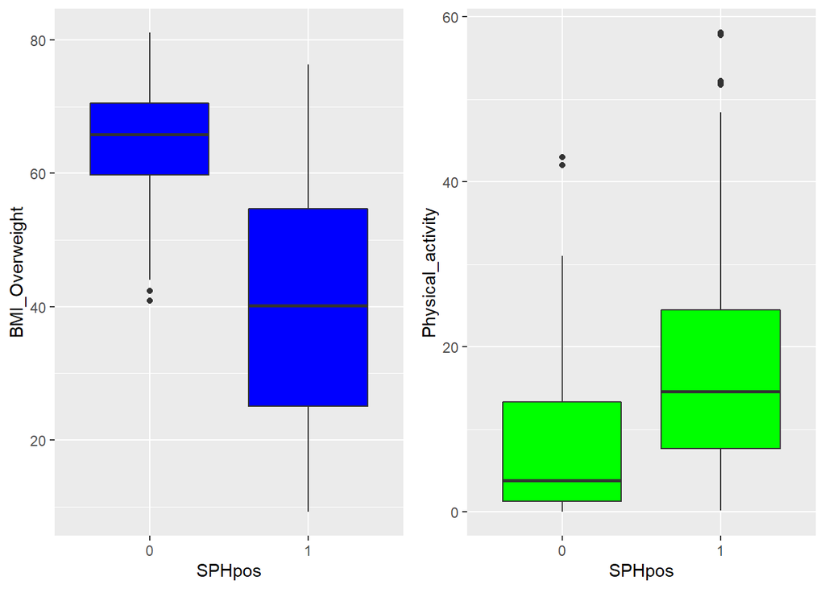

```r
grid.newpage()

plt.bidim.bmi <- ggplot(data = dfHDreg.corr, mapping = aes(x = SPHpos, y = BMI_Overweight)) + geom_boxplot(fill='blue')

plt.bidim.physact <- ggplot(data = dfHDreg.corr, mapping = aes(x = SPHpos, y = Physical_activity)) + geom_boxplot(fill='green')


grid.arrange(plt.bidim.bmi,plt.bidim.physact,nrow=1,ncol=2)
```

Se observa una clara diferencia entre los grupos que se corresponden con SPH bajo, que presentan mayor porcentaje de población con sobrepeso, y los de valoración del SPH positiva con menores valores de porcentaje en su distribución. Aún con cierto solapamiento se pueden percibir el porcentaje de sobrepeso como posible elemento de influencia.

En cuanto a la actividad física los grupos de valoración positiva presentan porcentajes de población mayores en su distribución, si bien en este caso el solapamiento es más acusado. Habrá que verificar su relevancia en el análisis posterior.

Estas relaciones entran dentro de lo esperable, hacer ejercicio y mantener un peso adecuado parecen mejorar la autopercepción de salud.

### Variables relativas al Consumo Diario de Frutas y Verduras.

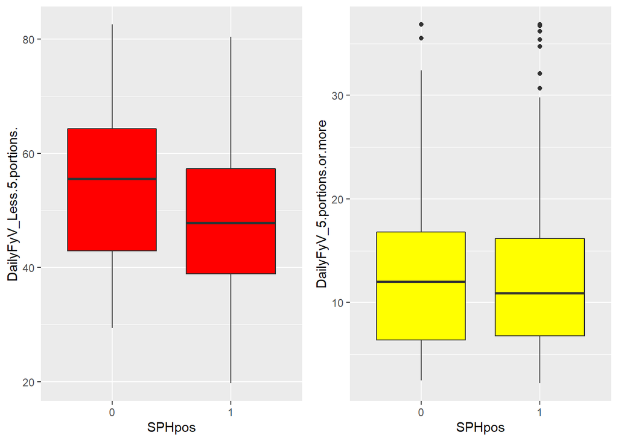

```r
grid.newpage()

plt.bidim.FyVless5 <- ggplot(data = dfHDreg.corr, mapping = aes(x = SPHpos, y = DailyFyV_Less.5.portions.)) + geom_boxplot(fill='red')

plt.bidim.FyV5more <- ggplot(data = dfHDreg.corr, mapping = aes(x = SPHpos, y = DailyFyV_5.portions.or.more)) + geom_boxplot(fill='yellow')


grid.arrange(plt.bidim.FyVless5,plt.bidim.FyV5more,nrow=1,ncol=2)
```

En cuanto al consumo diario de frutas y verduras, parece no haber prácticamente diferencias en las distribuciones de valores (porcentajes) en función de la SPH para aquellos grupos donde el consumo es el recomendado (5 raciones o más, variable ‘DailyFyV_5.portions.or.more’). Para los de consumo menor se observa una pequeña diferencia, con ligeramente mayores valores porcentuales los de SPH negativa.

Estudiados las distribuciones por separado y debido al solapamiento en las distribuciones, habrá que esperar al análisis junto con el resto de las variables.

### Variables relativas al Consumo de Tabaco.

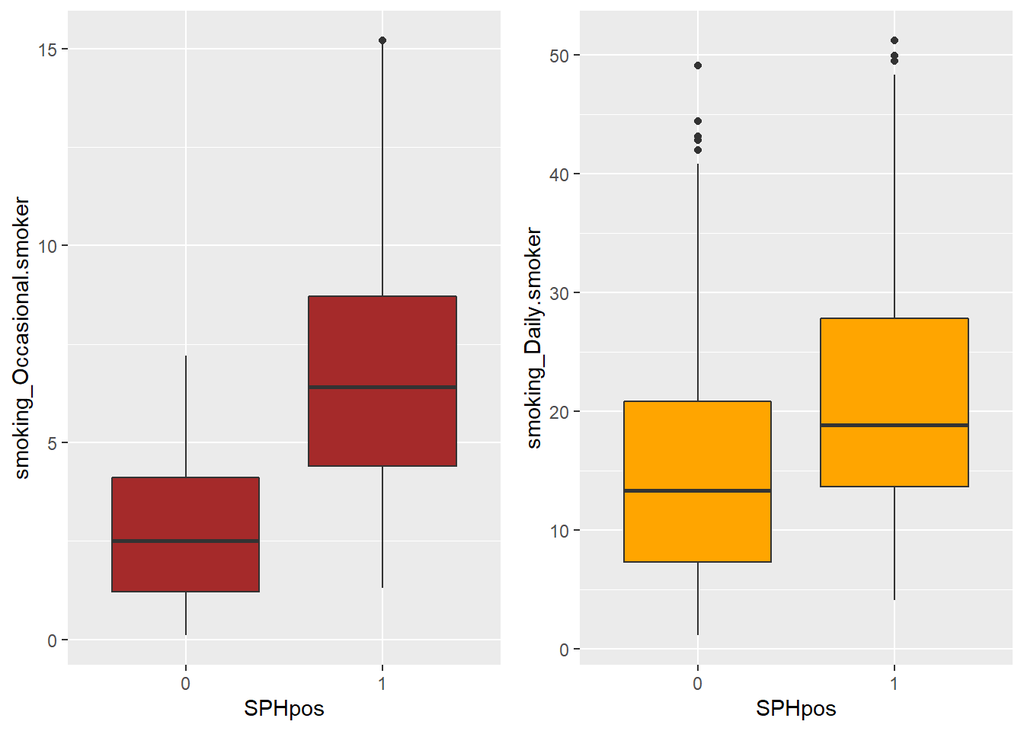

```r
grid.newpage()

plt.bidim.smkocas <- ggplot(data = dfHDreg.corr, mapping = aes(x = SPHpos, y = smoking_Occasional.smoker)) + geom_boxplot(fill='brown')

plt.bidim.smkday <- ggplot(data = dfHDreg.corr, mapping = aes(x = SPHpos, y = smoking_Daily.smoker)) + geom_boxplot(fill='orange')


grid.arrange(plt.bidim.smkocas,plt.bidim.smkday,nrow=1,ncol=2)
```

En cuanto al consumo de tabaco observamos con sorpresa para ambas variables una correspondencia entre valores mayores de porcentaje de población consumidora y valoración positiva del SPH, existiendo mayor solapamiento de las distribuciones en el caso de fumador diario.

El carácter de “auto percibido” de la variable objetivo puede relativizar esta aparente contradicción. A pesar de la certeza del perjuicio de consumo y de las campañas de sensibilización existentes, la propia población fumadora no paraece valorarla como factor negativo para su estado de salud.

Parecería tener mayor influencia la variable de Fumadores Ocasionales. Deberemos esperar a la fase de análisis.

### Variables relativas al Apoyo Social del entorno.

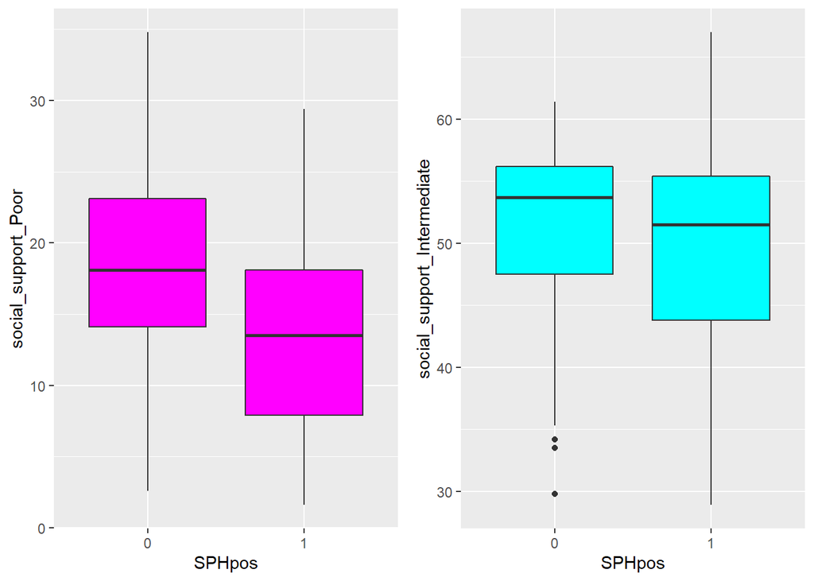

```r
grid.newpage()

plt.bidim.SocSupPoor <- ggplot(data = dfHDreg.corr, mapping = aes(x = SPHpos, y = social_support_Poor)) + geom_boxplot(fill='magenta')

plt.bidim.SocSupInt <- ggplot(data = dfHDreg.corr, mapping = aes(x = SPHpos, y = social_support_Intermediate)) + geom_boxplot(fill='cyan')


grid.arrange(plt.bidim.SocSupPoor,plt.bidim.SocSupInt,nrow=1,ncol=2)
```

Vemos en estas gráficas primero que los valores mayores porcentuales de Apoyo Social Pobre se asocian más con una percepción negativa del estado de salud, con una perceptible diferencia (aún con cierto solapamiento) entre las distribuciones de porcentajes. Para el caso de Apoyo Intermedio nos encontramos con distribuciones respecto a la SPH más similares (diferencia acaso de 5 puntos porcentuales en sus máximos).

Como factor parece entonces que el soporte social pobre podría ser determinante, habrá que corroborar la influencia o no en el análisis.

### Variables Tasa de Enfermedad Crónica y Uso de Medicinas No Prescribidas.

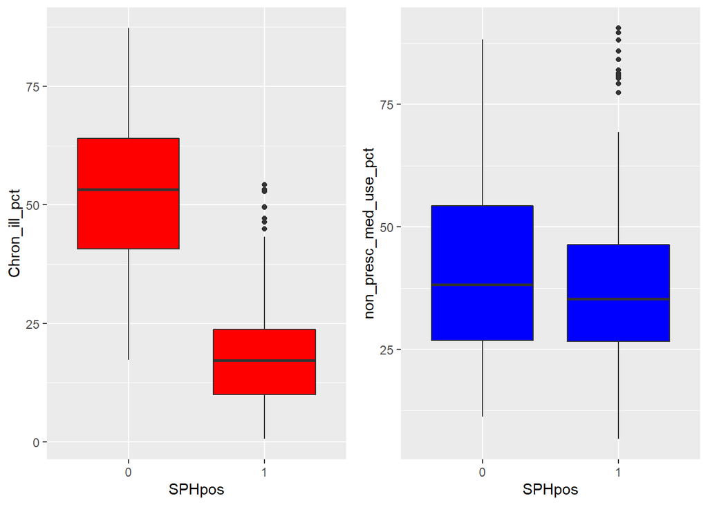

```r
grid.newpage()

plt.bidim.ChronIll<- ggplot(data = dfHDreg.corr, mapping = aes(x = SPHpos, y = Chron_ill_pct)) + geom_boxplot(fill='red')

plt.bidim.NonPrescrMed <- ggplot(data = dfHDreg.corr, mapping = aes(x = SPHpos, y = non_presc_med_use_pct)) + geom_boxplot(fill='blue')


grid.arrange(plt.bidim.ChronIll,plt.bidim.NonPrescrMed,nrow=1,ncol=2)
```

Se observa una por otro lado del todo esperable clara diferencia en las distribuciones de porcentaje para la Tasa de Enfermedad Crónica, con valores mayores de porcentaje de población con tal condición relacionado con SPH negativa y relativamente poco solapamiento entre ambas. Es entonces una candidata clara a factor determinante, a la espera de los resultados del análisis.

En cuanto al uso de medicinas no prescribidas, no existen grandes diferencias en las distribuciones, acaso estando más concentrada la de SPH positiva. Duda sobre su influencia, a la espera del análisis.

### Variables Gasto Sanitario y Tasa consumidores habituales de alcohol.

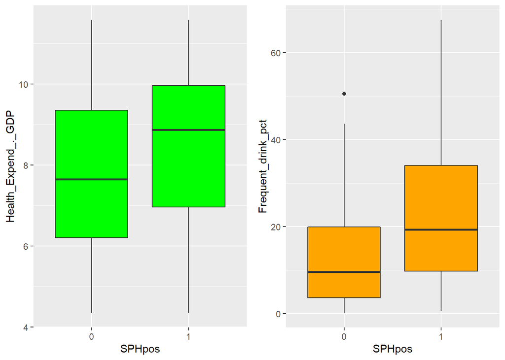

```r
grid.newpage()

plt.bidim.HlthExpend<- ggplot(data = dfHDreg.corr, mapping = aes(x = SPHpos, y = Health_Expend_._GDP)) + geom_boxplot(fill='green')

plt.bidim.FreqDrink <- ggplot(data = dfHDreg.corr, mapping = aes(x = SPHpos, y = Frequent_drink_pct)) + geom_boxplot(fill='orange')


grid.arrange(plt.bidim.HlthExpend,plt.bidim.FreqDrink,nrow=1,ncol=2)
```

Dentro del rango pequeño de valores en el que se mueve el gasto sanitario (en % del PIB), se distingue una pequeña diferencia en las distribuciones para cada valor de SPH, siendo mayores los porcentajes de gasto entre los de valoración positiva. Dada la situación de pequeña diferencia en un contexto de rango corto de valores, podría aventurarse compo posible que un mayor gasto en sanidad influya aún en forma ligeramente favorable, a falta de confirmarse en le análisis.

En cuanto a la Tasa de Bebedores Habituales, con cierto solapamiento en las distribuciones de valores, se observa al contrario de lo que en un principio se pudiera suponer que mayores porcentajes de poblacion bebedora habitual se asocian con SPH positiva. De nuevo aquí al igual que indicamos para el consumo de tabaco recordar el concepto de “auto percibida” de la variable objetivo, y la no valoración como negativa del consumo por parte de los bebedores frecuentes.

### Relación de la SPH con las variables AGE y SEX (categóricas, dimensiones).

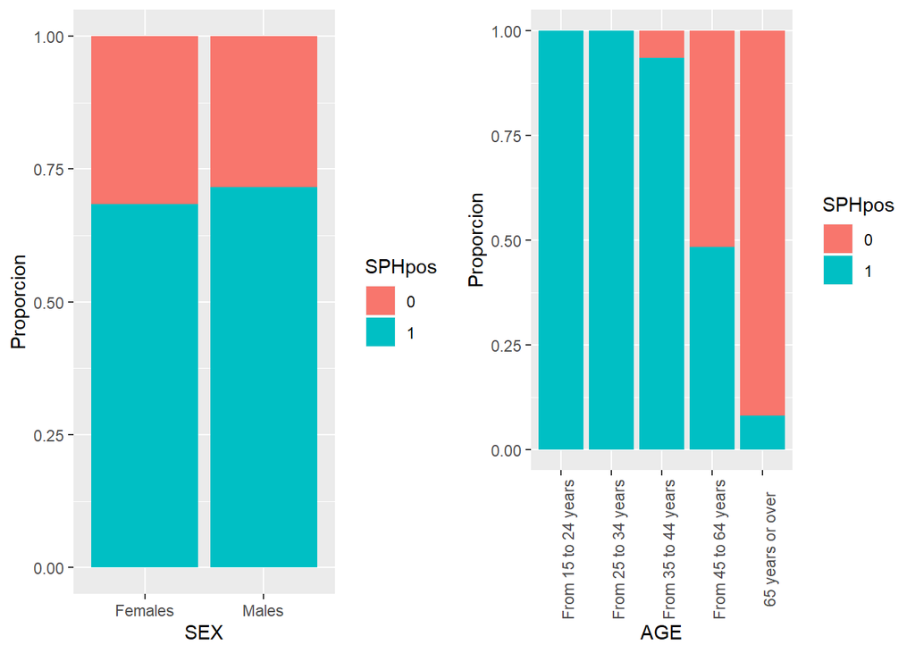

```r
grid.newpage()

plt.bidim.SPH_SEX<- ggplot(data=dfHDreg.corr,aes(x=SEX,fill=SPHpos))+geom_bar(position="fill")+ylab("Proporcion")

plt.bidim.SPH_AGE<- ggplot(data=dfHDreg.corr,aes(x=AGE,fill=SPHpos))+geom_bar(position="fill")+ylab("Proporcion") + theme(axis.text.x = element_text(angle = 90))


grid.arrange(plt.bidim.SPH_SEX,plt.bidim.SPH_AGE,nrow=1,ncol=2)
```

En primer lugar vemos que el género no parece determinante a la hora de diferenciar entre valoración positiva y negativa de salud, con proporciones similares entre hombres y mujeres (cerca del 75%, casi tres cuartas partes valoración positiva SPH)

En cuanto a los grupos de edad observamos hasta los 34 años la práctica ausencia de población que manifieste SPH negativa. Ésta aparece a partir de esos 35 años, aumentando en cada uno de los 3 grupos restantes con el aumento de edad. La franja entre 45 y 64 alcanza el 50% aproximadamente y en la tercera edad (65 o más) la valoración negativa es mayoritaria, sobre el 90%. Vemos pues una tendencia clara a valorar peor el estado de salud en los últimos intervalos de edad, previa a la tercera edad y en ella misma.

Veamos ahora la interacción entre las dos dimensiones.

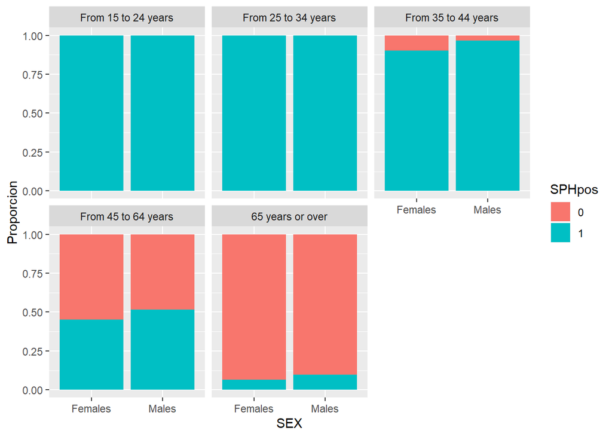

```r
ggplot(data = dfHDreg.corr,aes(x=SEX,fill=SPHpos))+geom_bar(position="fill")+
  facet_wrap(~AGE)+ylab("Proporcion")
```

No se observa diferencia en las proporciones por sexo en todos los grupos de edad, con valores prácticamente idénticos.

En un principio y a falta de los resultados del análisis con el resto de variables, parece que el género tiene menor influencia mientras que la edad si pudiera ser determinante.

### Guardado del dataset para la visualización en Tableau (dataset descriptivo).

```r
# NOTA: para la visualización en Tableau se decide añadir al dataset del análisis el valor de SPH # original (como porcentaje) por descriptivo, aparte del dicotomizado para la regresión logística

dfHDVisualiz <- dfHDreg.corr
dfHDVisualiz$SPH_pctg <- dfHD$SPH_G_or_VG_pct
str(dfHDVisualiz)
```

```
## 'data.frame':    310 obs. of  17 variables:
##  $ GEO                        : Factor w/ 31 levels "Austria","Belgium",..: 2 2 2 2 2 2 2 2 2 2 ...
##  $ SEX                        : Factor w/ 2 levels "Females","Males": 2 2 2 2 2 1 1 1 1 1 ...
##  $ AGE                        : Ord.factor w/ 5 levels "From 15 to 24 years"<..: 1 2 3 4 5 1 2 3 4 5 ...
##  $ BMI_Overweight             : num  18.7 41 54.1 65.8 65.6 15.6 36.9 35.4 46.6 54.5 ...
##  $ Physical_activity          : num  25.2 11.5 7.7 5.5 42 16.3 8.8 5.8 3.9 42 ...
##  $ DailyFyV_Less.5.portions.  : num  64.6 65.5 69.3 70.1 76 68.4 68.4 73.9 73.6 74.9 ...
##  $ DailyFyV_5.portions.or.more: num  10 8.2 11 11.6 12.2 6.5 11.5 14.2 16.9 15.5 ...
##  $ smoking_Occasional.smoker  : num  5.7 7.1 6 3.9 2.3 3.4 7.3 4.2 3.3 0.9 ...
##  $ smoking_Daily.smoker       : num  15.4 26.2 26.9 23.8 12.9 19.1 12.5 20.2 21.9 6.9 ...
##  $ Frequent_drink_pct         : num  50.1 45.3 43.1 37.7 20.1 35.6 17.5 16.9 17.9 9.7 ...
##  $ social_support_Poor        : num  11.5 14.7 17.7 20.4 19.1 15.8 9.1 18.1 17.6 21.1 ...
##  $ social_support_Intermediate: num  49.2 51.5 52.4 50 51.5 50.4 57.7 51.2 50.7 47.7 ...
##  $ Chron_ill_pct              : num  9.2 12.4 18.4 28 38.2 12.5 12.6 20.1 31.2 42.5 ...
##  $ Health_Expend_._GDP        : num  10.4 10.4 10.4 10.4 10.4 ...
##  $ non_presc_med_use_pct      : num  13.4 17.2 18.1 17 16.2 15.2 27.4 20.5 22.8 18.8 ...
##  $ SPHpos                     : Factor w/ 2 levels "0","1": 2 2 2 2 1 2 2 2 2 1 ...
##  $ SPH_pctg                   : num  94.8 89.4 83.8 74.5 53.3 91.7 88.8 79.8 70.1 50.4 ...
```

```r
write.csv(dfHDVisualiz,file = "./data/Hlth_Determ_EU_Vis_Tableau.csv", row.names = FALSE)
```

# 2.- ANÁLISIS DE LA INFLUENCIA DE LAS DISTINTAS VARIABLES. REGRESIÓN LOGÍSTICA, VALORACIÓN ODDS-RATIO.

## División del dataset en los conjuntos de entrenamiento y de test.

Realizamos primero la partición en los conjuntos train y test.

```r
# librería necesaria partición TRAIN-TEST
library(caret)
```

La función ‘createDataPartition’ permite hacer una partición estratificada, conservando los dos conjuntos resultantes TRAIN y TEST proporciones similares en cuanto a la variable objetivo (SPHpos) a la del conjunto en original.

```r
set.seed(42)

# Se crean los índices de las observaciones de entrenamiento

train.index <- createDataPartition(y = dfHDreg.corr$SPHpos, p = 0.8, list = FALSE, times = 1)

# creacion de los conjuntos
dfHD_train <- dfHDreg.corr[train.index, ]
dfHD_test  <- dfHDreg.corr[-train.index, ]


# revisamos tamaño de cada conjunto y proporciones variable target SPHpos

print("Dimensiones conjunto TRAIN:")
```

```
## [1] "Dimensiones conjunto TRAIN:"
```

```r
dim(dfHD_train)
```

```
## [1] 249  16
```

```r
print("Dimensiones conjunto TEST:")
```

```
## [1] "Dimensiones conjunto TEST:"
```

```r
dim(dfHD_test)
```

```
## [1] 61 16
```

```r
print("Proporción variable objetivo en dataset original:")
```

```
## [1] "Proporción variable objetivo en dataset original:"
```

```r
print(prop.table(table(dfHDreg.corr$SPHpos)))
```

```
##
##   0   1
## 0.3 0.7
```

```r
print("Proporción variable objetivo en conjunto TRAIN:")
```

```
## [1] "Proporción variable objetivo en conjunto TRAIN:"
```

```r
print(prop.table(table(dfHD_train$SPHpos)))
```

```
##
##         0         1
## 0.3012048 0.6987952
```

```r
print("Proporción variable objetivo en conjunto TEST:")
```

```
## [1] "Proporción variable objetivo en conjunto TEST:"
```

```r
print(prop.table(table(dfHD_test$SPHpos)))
```

```
##
##        0        1
## 0.295082 0.704918
```

Como vemos las proporciones de valores de la variable objetivo se conservan en ambos conjuntos.

## Estudio general en el ámbito europeo de los factores determinantes del estado de salud.Regresión logística SPHpos. Búsqueda del mejor modelo explicativo.

Primero debemos establecer los niveles de referencia para las variables explicativas categóricas. Para ello la variable AGE, cuyos niveles ordenamos para una mejor presentación en las gráficas del EDA, lo convertimos previamente en factor no ordenado.

Dado el ámbito global europeo de nuestro estudio de los factores determinantes de salud y para obtener conclusiones en conjunto, no haremos distinción por país. Hay que tener en cuenta además que debido al elevado número de países (31), se elevaría el número de variables para la regresión en un dataset ya con relativamente pocas observaciones, y dado que las diferencias entre países ya se mostrarán en posterior análisis PCA y clusterización, eliminamos del análisis la variable GEO.

```r
# nuevas variables estableciendo los niveles de referencia de las categóricas no ordenadas
# (necesario antes de la regresión logística)

dfHD_train$AGE <- factor(dfHD_train$AGE, ordered = FALSE)

dfHD_train$AGE_R <- relevel(dfHD_train$AGE, ref = "From 15 to 24 years")
dfHD_train$SEX_R <- relevel(dfHD_train$SEX, ref = "Males")



# eliminamos las originales (para evitar confusiones) y GEO

dfHD_train <- dfHD_train %>% dplyr::select(-GEO,-SEX,-AGE)

str(dfHD_train)
```

```
## 'data.frame':    249 obs. of  15 variables:
##  $ BMI_Overweight             : num  18.7 41 54.1 15.6 36.9 35.4 46.6 54.5 48.7 66.5 ...
##  $ Physical_activity          : num  25.2 11.5 7.7 16.3 8.8 5.8 3.9 42 17.5 9.2 ...
##  $ DailyFyV_Less.5.portions.  : num  64.6 65.5 69.3 68.4 68.4 73.9 73.6 74.9 26.1 38.9 ...
##  $ DailyFyV_5.portions.or.more: num  10 8.2 11 6.5 11.5 14.2 16.9 15.5 6.2 3.1 ...
##  $ smoking_Occasional.smoker  : num  5.7 7.1 6 3.4 7.3 4.2 3.3 0.9 8.4 7.3 ...
##  $ smoking_Daily.smoker       : num  15.4 26.2 26.9 19.1 12.5 20.2 21.9 6.9 45.8 48.3 ...
##  $ Frequent_drink_pct         : num  50.1 45.3 43.1 35.6 17.5 16.9 17.9 9.7 34 30.3 ...
##  $ social_support_Poor        : num  11.5 14.7 17.7 15.8 9.1 18.1 17.6 21.1 14 17 ...
##  $ social_support_Intermediate: num  49.2 51.5 52.4 50.4 57.7 51.2 50.7 47.7 52.9 57.6 ...
##  $ Chron_ill_pct              : num  9.2 12.4 18.4 12.5 12.6 20.1 31.2 42.5 5.8 7.4 ...
##  $ Health_Expend_._GDP        : num  10.4 10.4 10.4 10.4 10.4 ...
##  $ non_presc_med_use_pct      : num  13.4 17.2 18.1 15.2 27.4 20.5 22.8 18.8 20.3 26.2 ...
##  $ SPHpos                     : Factor w/ 2 levels "0","1": 2 2 2 2 2 2 2 1 2 2 ...
##  $ AGE_R                      : Factor w/ 5 levels "From 15 to 24 years",..: 1 2 3 1 2 3 4 5 2 3 ...
##  $ SEX_R                      : Factor w/ 2 levels "Males","Females": 1 1 1 2 2 2 2 2 1 1 ...
```

Llevamos a cabo la regresión logística:

```r
# libreria necesaria mejor modelo (selección de variables) "stepwise"
library(MASS)
```

En la búsqueda del mejor modelo (según criterio de información AIC) y las variables con influencia estadísticamente significativa, partiendo del modelo completo con todas las variables explicativas realizaremos mos un proceso de selección de variables del modelo (‘stepwise’) ‘backward’, en ambas direcciones ‘both’ y ‘forward’.

Probamos refinamiento con dirección ‘backward’

```r
# stepwise backward
mod.logist.completo <- glm(SPHpos ~ ., data = dfHD_train, family = binomial)

mod.stepwise.backward <- stepAIC(mod.logist.completo, direction = "backward", trace = TRUE)
```

```
## Start:  AIC=115.08
## SPHpos ~ BMI_Overweight + Physical_activity + DailyFyV_Less.5.portions. +
##     DailyFyV_5.portions.or.more + smoking_Occasional.smoker +
##     smoking_Daily.smoker + Frequent_drink_pct + social_support_Poor +
##     social_support_Intermediate + Chron_ill_pct + Health_Expend_._GDP +
##     non_presc_med_use_pct + AGE_R + SEX_R
##
##                               Df Deviance    AIC
## - AGE_R                        4   82.925 110.92
## - BMI_Overweight               1   79.130 113.13
## - social_support_Poor          1   79.137 113.14
## - non_presc_med_use_pct        1   79.159 113.16
## - SEX_R                        1   79.337 113.34
## - Frequent_drink_pct           1   79.575 113.58
## - DailyFyV_5.portions.or.more  1   79.594 113.59
## - smoking_Daily.smoker         1   80.133 114.13
## - Physical_activity            1   80.277 114.28
## - DailyFyV_Less.5.portions.    1   80.529 114.53
## <none>                             79.079 115.08
## - smoking_Occasional.smoker    1   81.696 115.70
## - social_support_Intermediate  1   81.821 115.82
## - Health_Expend_._GDP          1   84.827 118.83
## - Chron_ill_pct                1   87.985 121.98
##
## Step:  AIC=110.92
## SPHpos ~ BMI_Overweight + Physical_activity + DailyFyV_Less.5.portions. +
##     DailyFyV_5.portions.or.more + smoking_Occasional.smoker +
##     smoking_Daily.smoker + Frequent_drink_pct + social_support_Poor +
##     social_support_Intermediate + Chron_ill_pct + Health_Expend_._GDP +
##     non_presc_med_use_pct + SEX_R
##
##                               Df Deviance    AIC
## - non_presc_med_use_pct        1   82.925 108.92
## - Frequent_drink_pct           1   82.961 108.96
## - Physical_activity            1   83.268 109.27
## - smoking_Daily.smoker         1   83.581 109.58
## - social_support_Poor          1   84.030 110.03
## - social_support_Intermediate  1   84.106 110.11
## - DailyFyV_Less.5.portions.    1   84.344 110.34
## - DailyFyV_5.portions.or.more  1   84.455 110.45
```

[output cut: 85 more lines]

```
## Step:  AIC=103.04
## SPHpos ~ BMI_Overweight + DailyFyV_Less.5.portions. + DailyFyV_5.portions.or.more +
##     smoking_Occasional.smoker + social_support_Poor + Chron_ill_pct +
##     Health_Expend_._GDP + SEX_R
##
##                               Df Deviance    AIC
## <none>                             85.039 103.04
## - DailyFyV_Less.5.portions.    1   87.293 103.29
## - SEX_R                        1   88.025 104.03
## - DailyFyV_5.portions.or.more  1   88.162 104.16
## - BMI_Overweight               1   88.209 104.21
## - Health_Expend_._GDP          1   89.563 105.56
## - social_support_Poor          1   91.580 107.58
## - smoking_Occasional.smoker    1   91.739 107.74
## - Chron_ill_pct                1  113.434 129.43
```

```r
# resumen mejor modelo alcanzado
summary(mod.stepwise.backward)
```

```
##
## Call:
## glm(formula = SPHpos ~ BMI_Overweight + DailyFyV_Less.5.portions. +
##     DailyFyV_5.portions.or.more + smoking_Occasional.smoker +
##     social_support_Poor + Chron_ill_pct + Health_Expend_._GDP +
##     SEX_R, family = binomial, data = dfHD_train)
##
## Deviance Residuals:
##      Min        1Q    Median        3Q       Max
## -2.26688  -0.04643   0.04430   0.15504   2.29398
##
## Coefficients:
##                             Estimate Std. Error z value Pr(>|z|)
## (Intercept)                  2.31409    3.67165   0.630   0.5285
## BMI_Overweight              -0.06026    0.03665  -1.644   0.1001
## DailyFyV_Less.5.portions.    0.04738    0.03197   1.482   0.1384
## DailyFyV_5.portions.or.more  0.08674    0.05103   1.700   0.0892 .
## smoking_Occasional.smoker    0.50580    0.21277   2.377   0.0174 *
## social_support_Poor         -0.11658    0.04746  -2.457   0.0140 *
## Chron_ill_pct               -0.13709    0.03309  -4.142 3.44e-05 ***
## Health_Expend_._GDP          0.37567    0.18155   2.069   0.0385 *
## SEX_RFemales                -1.53159    0.91629  -1.672   0.0946 .
## ---
## Signif. codes:  0 '***' 0.001 '**' 0.01 '*' 0.05 '.' 0.1 ' ' 1
##
## (Dispersion parameter for binomial family taken to be 1)
##
##     Null deviance: 304.717  on 248  degrees of freedom
## Residual deviance:  85.039  on 240  degrees of freedom
## AIC: 103.04
##
## Number of Fisher Scoring iterations: 8
```

**NOTA:** se hicieron pruebas siguiendo la traza con modelos de valores de AIC algo mayores pero cercanos, para ver si podíamos incluir más variables estadísticamente significativas, sin éxito.

A continuación en ambas direcciones:

```r
mod.stepwise.both <- stepAIC(mod.logist.completo, direction = "both", trace = TRUE)
```

```
## Start:  AIC=115.08
## SPHpos ~ BMI_Overweight + Physical_activity + DailyFyV_Less.5.portions. +
##     DailyFyV_5.portions.or.more + smoking_Occasional.smoker +
##     smoking_Daily.smoker + Frequent_drink_pct + social_support_Poor +
##     social_support_Intermediate + Chron_ill_pct + Health_Expend_._GDP +
##     non_presc_med_use_pct + AGE_R + SEX_R
##
##                               Df Deviance    AIC
## - AGE_R                        4   82.925 110.92
## - BMI_Overweight               1   79.130 113.13
## - social_support_Poor          1   79.137 113.14
## - non_presc_med_use_pct        1   79.159 113.16
## - SEX_R                        1   79.337 113.34
## - Frequent_drink_pct           1   79.575 113.58
## - DailyFyV_5.portions.or.more  1   79.594 113.59
## - smoking_Daily.smoker         1   80.133 114.13
## - Physical_activity            1   80.277 114.28
## - DailyFyV_Less.5.portions.    1   80.529 114.53
## <none>                             79.079 115.08
## - smoking_Occasional.smoker    1   81.696 115.70
## - social_support_Intermediate  1   81.821 115.82
## - Health_Expend_._GDP          1   84.827 118.83
## - Chron_ill_pct                1   87.985 121.98
##
## Step:  AIC=110.92
## SPHpos ~ BMI_Overweight + Physical_activity + DailyFyV_Less.5.portions. +
##     DailyFyV_5.portions.or.more + smoking_Occasional.smoker +
##     smoking_Daily.smoker + Frequent_drink_pct + social_support_Poor +
##     social_support_Intermediate + Chron_ill_pct + Health_Expend_._GDP +
##     non_presc_med_use_pct + SEX_R
##
##                               Df Deviance    AIC
## - non_presc_med_use_pct        1   82.925 108.92
## - Frequent_drink_pct           1   82.961 108.96
## - Physical_activity            1   83.268 109.27
## - smoking_Daily.smoker         1   83.581 109.58
## - social_support_Poor          1   84.030 110.03
## - social_support_Intermediate  1   84.106 110.11
## - DailyFyV_Less.5.portions.    1   84.344 110.34
## - DailyFyV_5.portions.or.more  1   84.455 110.45
```

[output cut: 106 more lines]

```
## <none>                             85.039 103.04
## - DailyFyV_Less.5.portions.    1   87.293 103.29
## + social_support_Intermediate  1   83.925 103.92
## - SEX_R                        1   88.025 104.03
## - DailyFyV_5.portions.or.more  1   88.162 104.16
## - BMI_Overweight               1   88.209 104.21
## + smoking_Daily.smoker         1   84.264 104.26
## + non_presc_med_use_pct        1   84.955 104.95
## + Physical_activity            1   85.029 105.03
## + Frequent_drink_pct           1   85.039 105.04
## - Health_Expend_._GDP          1   89.563 105.56
## - social_support_Poor          1   91.580 107.58
## - smoking_Occasional.smoker    1   91.739 107.74
## + AGE_R                        4   82.747 108.75
## - Chron_ill_pct                1  113.434 129.43
```

```r
summary(mod.stepwise.both)
```

```
##
## Call:
## glm(formula = SPHpos ~ BMI_Overweight + DailyFyV_Less.5.portions. +
##     DailyFyV_5.portions.or.more + smoking_Occasional.smoker +
##     social_support_Poor + Chron_ill_pct + Health_Expend_._GDP +
##     SEX_R, family = binomial, data = dfHD_train)
##
## Deviance Residuals:
##      Min        1Q    Median        3Q       Max
## -2.26688  -0.04643   0.04430   0.15504   2.29398
##
## Coefficients:
##                             Estimate Std. Error z value Pr(>|z|)
## (Intercept)                  2.31409    3.67165   0.630   0.5285
## BMI_Overweight              -0.06026    0.03665  -1.644   0.1001
## DailyFyV_Less.5.portions.    0.04738    0.03197   1.482   0.1384
## DailyFyV_5.portions.or.more  0.08674    0.05103   1.700   0.0892 .
## smoking_Occasional.smoker    0.50580    0.21277   2.377   0.0174 *
## social_support_Poor         -0.11658    0.04746  -2.457   0.0140 *
## Chron_ill_pct               -0.13709    0.03309  -4.142 3.44e-05 ***
## Health_Expend_._GDP          0.37567    0.18155   2.069   0.0385 *
## SEX_RFemales                -1.53159    0.91629  -1.672   0.0946 .
## ---
## Signif. codes:  0 '***' 0.001 '**' 0.01 '*' 0.05 '.' 0.1 ' ' 1
##
## (Dispersion parameter for binomial family taken to be 1)
##
##     Null deviance: 304.717  on 248  degrees of freedom
## Residual deviance:  85.039  on 240  degrees of freedom
## AIC: 103.04
##
## Number of Fisher Scoring iterations: 8
```

Llegamos al mismo mejor modelo que el anterior, con los mismos valores para los coeficientes y su significancia. De nuevo probamos con modelos de la traza sin éxito.

Probamos la última posibilidad, dirección del refinamiento ‘forward’:

```r
# parte del modelo 'vacio' (solo una constante)
mod.logist.cero <- glm(SPHpos ~ 1, data = dfHD_train, family = binomial)

mod.stepwise.forward <- stepAIC(mod.logist.cero, direction = "forward", trace = TRUE)
```

```
## Start:  AIC=306.72
## SPHpos ~ 1
```

```r
summary(mod.stepwise.forward)
```

```
##
## Call:
## glm(formula = SPHpos ~ 1, family = binomial, data = dfHD_train)
##
## Deviance Residuals:
##     Min       1Q   Median       3Q      Max
## -1.5492  -1.5492   0.8466   0.8466   0.8466
##
## Coefficients:
##             Estimate Std. Error z value Pr(>|z|)
## (Intercept)   0.8416     0.1381   6.092 1.11e-09 ***
## ---
## Signif. codes:  0 '***' 0.001 '**' 0.01 '*' 0.05 '.' 0.1 ' ' 1
##
## (Dispersion parameter for binomial family taken to be 1)
##
##     Null deviance: 304.72  on 248  degrees of freedom
## Residual deviance: 304.72  on 248  degrees of freedom
## AIC: 306.72
##
## Number of Fisher Scoring iterations: 4
```

Sin resultados.

Nos quedamos pues con el mejor modelo, el mismo encontrado para las direcciones de selección ‘backward’ y ‘both’.

```r
summary(mod.stepwise.both)
```

```
##
## Call:
## glm(formula = SPHpos ~ BMI_Overweight + DailyFyV_Less.5.portions. +
##     DailyFyV_5.portions.or.more + smoking_Occasional.smoker +
##     social_support_Poor + Chron_ill_pct + Health_Expend_._GDP +
##     SEX_R, family = binomial, data = dfHD_train)
##
## Deviance Residuals:
##      Min        1Q    Median        3Q       Max
## -2.26688  -0.04643   0.04430   0.15504   2.29398
##
## Coefficients:
##                             Estimate Std. Error z value Pr(>|z|)
## (Intercept)                  2.31409    3.67165   0.630   0.5285
## BMI_Overweight              -0.06026    0.03665  -1.644   0.1001
## DailyFyV_Less.5.portions.    0.04738    0.03197   1.482   0.1384
## DailyFyV_5.portions.or.more  0.08674    0.05103   1.700   0.0892 .
## smoking_Occasional.smoker    0.50580    0.21277   2.377   0.0174 *
## social_support_Poor         -0.11658    0.04746  -2.457   0.0140 *
## Chron_ill_pct               -0.13709    0.03309  -4.142 3.44e-05 ***
## Health_Expend_._GDP          0.37567    0.18155   2.069   0.0385 *
## SEX_RFemales                -1.53159    0.91629  -1.672   0.0946 .
## ---
## Signif. codes:  0 '***' 0.001 '**' 0.01 '*' 0.05 '.' 0.1 ' ' 1
##
## (Dispersion parameter for binomial family taken to be 1)
##
##     Null deviance: 304.717  on 248  degrees of freedom
## Residual deviance:  85.039  on 240  degrees of freedom
## AIC: 103.04
##
## Number of Fisher Scoring iterations: 8
```

### Validación del modelo.

#### Devianza

En primer lugar para comprobar la bondad del ajuste del modelo logístico utilizamos como indicador usual la devianza, que se define como menos el doble del logaritmo de la razón de verosimilitud (log-likelihood), es decir, devianza=−2× log-likelihood y se representa como -2LL.

La devianza tiene una distribución χ2 y compara los valores de la predicción observados en dos momentos:

- El modelo sin variables independientes, sólo con la constante (modelo referencia).
- El modelo con las variables predictoras introducidas.

Simplemente de los valores devueltos en el resumen de nuestro modelo tomamos la devianza del modelo referencia (valor ‘Null deviance’) y le restamos la devianza del nuevo modelo (valor ‘Residual Deviance’). Estos valores son accesibles desde la propia variable donde almacenamos nuestro modelo.

Esta diferencia se lo conoce como “likelihood-ratio” y tiene una distribución χ2 con k-1 grados de libertad, el número de parámetros del nuevo modelo, menos el número de parámetros del modelo referencia que es siempre 1.

Para calcular la probabilidad asociada al estadístico chi-cuadrado utilizamos la función pchisq(Chi, gl), cuyos argumentos son el estadístico chi-cuadrado y sus grados de libertad. La probabilidad que queremos es 1 menos el valor de la función pchisq().

```r
# estadístico chi-cuadrado
estad.chi <- mod.stepwise.both$null.deviance - mod.stepwise.both$deviance

# grados de libertad
grad.lib.chi <- mod.stepwise.both$df.null - mod.stepwise.both$df.residual

# p-valor
p_valor <- 1 - pchisq(estad.chi, grad.lib.chi)

p_valor
```

```
## [1] 0
```

La probabilidad es menor que 0.05, por lo tanto podemos afirmar que el modelo en conjunto es significativo.

#### Multicolinealidad.

Verificaremos la posible existencia de multicolinealidad, que afectaría gravemente a la interpretación de los resultados de la regresión, con el cálculo del factor de inflacción de la varianza de todas las variables independientes:

```r
# librería necesaria función 'vif()'

library(car)
```

```r
# cálculo del factor de inflacción de la varianza de todas las variables independientes

vif(mod.stepwise.both)
```

```
##              BMI_Overweight   DailyFyV_Less.5.portions.
##                    2.468416                    2.052280
## DailyFyV_5.portions.or.more   smoking_Occasional.smoker
##                    2.099753                    1.888218
##         social_support_Poor               Chron_ill_pct
##                    1.345774                    2.109755
##         Health_Expend_._GDP                       SEX_R
##                    1.531077                    2.710311
```

El valor mínimo de VIF es 1, se suelen tomar como umbral máximo indicador de multicolinealidad el valor 10, aunque en algunos estudios ya toman por encima de 5 como indicador posible de multicolinealidad. En nuestro caso todos los valores se situan por debajo de ambos umbrales, luego podemos en este aspecto dar nuestro modelo como válido.

#### Métricas de clasificación.

A continuación analizaremos las métricas usuales de clasificación (SPHpos ‘0’ o ‘1’).Para ello debemos antes que nada realizar sobre el conjunto TEST las mismas operaciones de preparación que realizamos en cuanto a las variables categóricas para el conjunto TRAIN:

```r
# nuevas variables estableciendo los niveles de referencia de las categóricas no ordenadas
# (necesario antes de la regresión logística)

dfHD_test$AGE <- factor(dfHD_test$AGE, ordered = FALSE)

dfHD_test$AGE_R <- relevel(dfHD_test$AGE, ref = "From 15 to 24 years")
dfHD_test$SEX_R <- relevel(dfHD_test$SEX, ref = "Males")


# eliminamos las originales (para evitar confusiones) y GEO

dfHD_test <- dfHD_test %>% dplyr::select(-GEO,-SEX,-AGE)

str(dfHD_test)
```

```
## 'data.frame':    61 obs. of  15 variables:
##  $ BMI_Overweight             : num  65.8 65.6 26.1 80.6 25.1 21.6 54.2 66.3 44.8 64.3 ...
##  $ Physical_activity          : num  5.5 42 24.5 3.4 9.4 48.1 22.6 21.6 21.4 2.1 ...
##  $ DailyFyV_Less.5.portions.  : num  70.1 76 34.6 41.3 57.2 23.6 33.6 37.3 42.8 52.5 ...
##  $ DailyFyV_5.portions.or.more: num  11.6 12.2 4.8 5 11.4 18.6 18.7 17 28.9 11.9 ...
##  $ smoking_Occasional.smoker  : num  3.9 2.3 8.2 5.8 11 13 5.4 4.6 2.9 1.8 ...
##  $ smoking_Daily.smoker       : num  23.8 12.9 25.5 29.9 16.8 9.7 16.5 17.9 8.8 16.4 ...
##  $ Frequent_drink_pct         : num  37.7 20.1 18.3 19.9 14 58.7 44.7 47.2 16.8 14.3 ...
##  $ social_support_Poor        : num  20.4 19.1 10.7 15.5 8.6 15.4 12.5 18.1 26.7 18.7 ...
##  $ social_support_Intermediate: num  50 51.5 53.6 57.5 44.3 48.3 50.1 50.8 47.4 59.9 ...
##  $ Chron_ill_pct              : num  28 38.2 3.8 32.9 10.9 14.8 23.5 32.7 37 80.5 ...
##  $ Health_Expend_._GDP        : num  10.44 10.44 7.71 7.65 7.65 ...
##  $ non_presc_med_use_pct      : num  17 16.2 18.4 39.6 51.6 40.1 46.6 49.9 67.3 44.5 ...
##  $ SPHpos                     : Factor w/ 2 levels "0","1": 2 1 2 1 2 2 2 2 1 1 ...
##  $ AGE_R                      : Factor w/ 5 levels "From 15 to 24 years",..: 4 5 1 4 2 1 3 4 5 5 ...
##  $ SEX_R                      : Factor w/ 2 levels "Males","Females": 1 1 1 1 2 1 1 1 2 1 ...
```

Pasamos ahora al cálculo de la matriz de confusión y principales métricas de bondad del ajuste (clasificación) que se derivan de ella. Para ello realizamos las predicciones de nuestro modelo con los datos del conjunto TEST y nos valemos de la función ‘confusionMatrix’ del paquete ‘caret’, que realiza dichos cálculos proporcionando nosotros los valores reales del SPH.

```r
predicciones <- round(predict(mod.stepwise.both, newdata = dfHD_test, type = "response"))

confusionMatrix(data = as.factor(predicciones), reference = dfHD_test$SPHpos, positive = "1",
                dnn = c("observaciones","predicciones"), mode = "prec_recall")
```

```
## Confusion Matrix and Statistics
##
##              predicciones
## observaciones  0  1
##             0 15  2
##             1  3 41
##
##                Accuracy : 0.918
##                  95% CI : (0.819, 0.9728)
##     No Information Rate : 0.7049
##     P-Value [Acc > NIR] : 5.204e-05
##
##                   Kappa : 0.7997
##
##  Mcnemar's Test P-Value : 1
##
##               Precision : 0.9318
##                  Recall : 0.9535
##                      F1 : 0.9425
##              Prevalence : 0.7049
##          Detection Rate : 0.6721
##    Detection Prevalence : 0.7213
##       Balanced Accuracy : 0.8934
##
##        'Positive' Class : 1
##
```

En la matriz de confusión podemos observar solo 5 clasificaciones erroneas de entre las 61 observaciones totales del conjunto TEST.

Como vemos nuestro modelo alcanza buenos valores tanto del primer objetivo de precisión (‘accuracy’, 91.8%) como de entre otros los valores ‘precision’, ‘recall’ y ‘f1’, usuales métricas de clasificación, todas por encima del 93%.

Para terminar con la validación del modelo dibujamos la curva ROC correspondiente a nuestro modelo y calculamos el área bajo esa curva.

```r
# libreria necesaria cálculo ROC
library(ROCR)
```

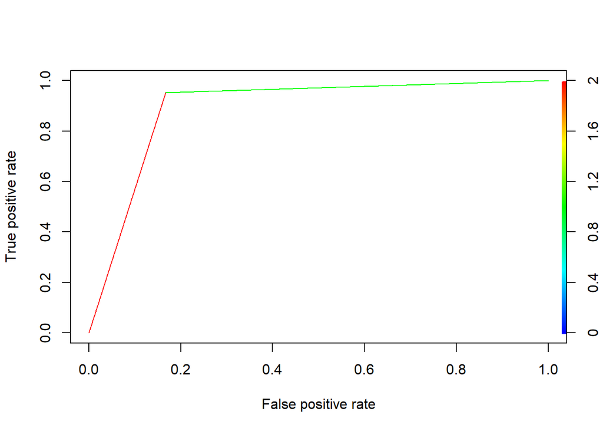

```r
# función 'prediction' de lamisma librería, necesaria para la grafica
predicciones.ROCR = prediction(predicciones, dfHD_test$SPHpos)

# cálculo ROC
ROCR.Perf = performance(predicciones.ROCR, "tpr", "fpr")

# dbujo gráfica
plot(ROCR.Perf, colorize = TRUE)
```

```r
# función performance de la misma librería
auc = as.numeric(performance(predicciones.ROCR,"auc")@y.values)

# Valor AUC
print(auc)
```

```
## [1] 0.8934109
```

Como se puede comprobar con la curva ROC cercana a la esquina superior izquierda y el valor alto del AUC, se corrobora nuestro modelo como bastante bueno, con lo cual podemos pasar a la evaluación de los odds-ratio.

## Evaluación de los factores determinantes: valoración de los odds-ratio.

Comprobada la bondad de nuestro modelo, obtenemos a partir de los coeficientes de ajuste los odds-ratio de la variables determinantes (con significancia estadística).

Debemos comentar que, con un nivel de significancia del 10% (0.1), recuperamos también la variable ‘BMI_Overweight’ por sobrepasar el valor de significancia por muy poco (0.1001) y dada su relevancia para el análisis.

Mostramos pues finalmente las odds-ratio de las variables determinantes (significancia estadística) con sus intervalos de confianza, y pasamos a su evaluación. Es necesario recordar que las unidades de estas variables son porcentajes, sobre el PIB para la variable ‘Gasto sanitario’ y para el resto porcentaje de población que cumple o se encuentra en la situación que indica el nombre de la variable.

```r
# resumen mejor modelo
summary(mod.stepwise.both)
```

```
##
## Call:
## glm(formula = SPHpos ~ BMI_Overweight + DailyFyV_Less.5.portions. +
##     DailyFyV_5.portions.or.more + smoking_Occasional.smoker +
##     social_support_Poor + Chron_ill_pct + Health_Expend_._GDP +
##     SEX_R, family = binomial, data = dfHD_train)
##
## Deviance Residuals:
##      Min        1Q    Median        3Q       Max
## -2.26688  -0.04643   0.04430   0.15504   2.29398
##
## Coefficients:
##                             Estimate Std. Error z value Pr(>|z|)
## (Intercept)                  2.31409    3.67165   0.630   0.5285
## BMI_Overweight              -0.06026    0.03665  -1.644   0.1001
## DailyFyV_Less.5.portions.    0.04738    0.03197   1.482   0.1384
## DailyFyV_5.portions.or.more  0.08674    0.05103   1.700   0.0892 .
## smoking_Occasional.smoker    0.50580    0.21277   2.377   0.0174 *
## social_support_Poor         -0.11658    0.04746  -2.457   0.0140 *
## Chron_ill_pct               -0.13709    0.03309  -4.142 3.44e-05 ***
## Health_Expend_._GDP          0.37567    0.18155   2.069   0.0385 *
## SEX_RFemales                -1.53159    0.91629  -1.672   0.0946 .
## ---
## Signif. codes:  0 '***' 0.001 '**' 0.01 '*' 0.05 '.' 0.1 ' ' 1
##
## (Dispersion parameter for binomial family taken to be 1)
##
##     Null deviance: 304.717  on 248  degrees of freedom
## Residual deviance:  85.039  on 240  degrees of freedom
## AIC: 103.04
##
## Number of Fisher Scoring iterations: 8
```

```r
# calculo odds-ratio e intervalos de confianza a partir de los resultados del modelo

print("Odds-ratio variables determinantes (significancia estadística):")
```

```
## [1] "Odds-ratio variables determinantes (significancia estadística):"
```

```r
odds.ratio <- exp(coefficients(mod.stepwise.both))

var.determ <- c("BMI_Overweight","DailyFyV_5.portions.or.more","smoking_Occasional.smoker",
                "social_support_Poor","Chron_ill_pct","Health_Expend_._GDP","SEX_RFemales")

conf.int <- exp(confint(mod.stepwise.both, level = 0.90))
# odds-ratio e intervalos de confianza para las variables estadísticamente significativas
print(odds.ratio[var.determ])
```

```
##              BMI_Overweight DailyFyV_5.portions.or.more
##                   0.9415207                   1.0906083
##   smoking_Occasional.smoker         social_support_Poor
##                   1.6583096                   0.8899614
##               Chron_ill_pct         Health_Expend_._GDP
##                   0.8718911                   1.4559706
##                SEX_RFemales
##                   0.2161924
```

```r
print(conf.int[var.determ,])
```

```
##                                    5 %      95 %
## BMI_Overweight              0.88230542 0.9957348
## DailyFyV_5.portions.or.more 1.00584828 1.1912773
## smoking_Occasional.smoker   1.19118242 2.4084185
## social_support_Poor         0.82009911 0.9599426
## Chron_ill_pct               0.82149695 0.9166357
## Health_Expend_._GDP         1.08753314 1.9848585
## SEX_RFemales                0.04470736 0.9306222
```

Como vemos las variables que afectan negativamente a la SPHpos (oods-ratio inferior a la unidad) son ‘BMI_Overweight’, ‘social_support_Poor’, ‘Chron_ill_pct’ y ‘SEX_RFemales’ (en referencia al género masculino)

Las que afectan en forma positiva (oods-ratio mayor que la unidad) son ‘DailyFyV_5.portions.or.more’, ‘Health_Expend_._GDP’ y sorpresivamente ‘smoking_Occasional.smoker’

El resto de las variables con las que partíamos han sido eliminadas en el proceso de refinamiento (stepwise-both) por no ser influyentes (no estadísticamente significativas).

Pasamos a comentar cada una de ellas:

### BMI_Overweight

Como vemos por su odds-ratio (0.9415) el sobrepeso afecta negativamente a la autovaloración del estado de salud (SPHpos). El valor nos indica que por cada aumento en la variable independiente de un punto porcentual la probabilidad de tener valoración positiva se multiplica por 0.94, es decir baja casi un 6% respecto a la anterior del aumento del punto porcentual.

Entre los factores negativos es el que influye de forma más leve.

### DailyFyV_5.portions.or.more

Tiene un odds-ratio de 1.0906. Por lo tanto tomar al menos la dosis diaria recomendada de frutas y verduras es positivo para la autovaloración del estado de salud, si bien la influencia es de grado leve.

Por cada aumento de un punto porcentual en el consumo la probabilidad de tener valoración positiva aumenta casi en un 9.06% respecto a antes del aumento.

### smoking_Occasional.smoker

Con un odds-ratio de 1.6583, nos indica para nuestra sorpresa que tal condición (porcentaje de población con ésta) es un factor positivo para la autovaloración del estado de salud. Situando este dato en su contexto debemos recordar que ya en el análisis exploratorio, y tanto para los fumadores ocasionales como los diarios, los valores más altos de porcentaje fumadora se encontraban en la distribución de los que referian valoración positiva de salud.

Dado el carácter de ‘autopercibida’ del estado de salud de la SPH, junto con lo anterior comentado y dado el comprobado perjuicio sobre la salud del tabaco, todo esto podría indicar una mala o deficiente percepción por parte de la población fumadora (no achacable a la falta de información, presente de sobra) del perjuicio de su consumo.

Cada aumento de un punto porcentual de población fumadora ocasional multiplica la probabilidad de tener valoración positiva por 1.66 respecto a antes del aumento. Aumento que se pudiera considerar de excesivo y que situamos dentro del contexto explicado anteriormente.

### social_support_Poor

En este caso tenemos un odds-ratio de 0.8899, prácticamente 0.89. Como era esperable y se dejaba entrever la posibilidad en el análisis exploratorio, la percepción de falta de apoyo social (del entorno) afecta negativamente a la autovaloración del estado de salud.

Este valor nos dice que por cada aumento de un punto porcentual de la población con esta circunstancia la probabilidad de tener valoración positiva baja en un 11% respecto a antes del aumento.

### Chron_ill_pct

Su odds-ratio es de 0.8719. Del todo esperable, la condición de vivir bajo una enfermedad o dolencia crónica afecta negativamente a la autovaloración del estado de salud.

Por cada aumento de un punto porcentual de la población en esta condición la probabilidad de tener valoración positiva baja en un 12.81% respecto al anterior.

La enfermedad crónica junto con la anterior apoyo social escaso son los factores que más inciden en una valoración negativa de la salud.

### Health_Expend_._GDP

Tiene un odds-ratio de 1.4559. Este valor parece indicar que el esfuerzo en aumento del gasto en sanidad obtiene resultados, reflejándose en una autovaloración positiva del estado de salud de la población.

El aumento de un punto porcentual sobre el PIB del Gasto Sanitario supone aumentar la probabilidad de tener valoración positiva en un nada despreciable 45.6% sobre el anterior. Este grado de influencia pudiera justificarse con los mejores y en mayor número recursos sanitarios ofrecidos a su población si se aumenta el gasto y la percepción de la población ante esta mejora.

### SEX_RFemales

Esta variable tiene un odds-ratio de 0.2161924, tomado como referencia al masculino. La dismi nución en la auto percepción del estado de salud de las mujeres respecto a la de los hombres es considerable.

La probabilidad de tener valoración positiva al ser mujer disminuye en un 78.4% repecto a la del hombre.

# 3.- ANÁLISIS DE LOS DATOS POR PAÍS. ANÁLISIS DE COMPONENTES PRINCIPALES.

Dado el número elevado de variables de las que disponemos (15) y que estudiando por país se nos quedan 31 observaciones, decidimos realizar un análisis PCA y estudiar la carga (pesos de las variables originales) en los factores resultado de la misma.

## 3.1 Análisis de componentes principales (PCA)

### Cálculo PCA

Agrupamos primero nuestro dataset por país:

```r
# agrupación por país
dfHD.pais.num <- dfHDreg.corr %>% dplyr::select(-SEX, -AGE, -SPHpos) %>% group_by(GEO) %>% summarize_all(~mean(.))

# resumen nuevo dataset
str(dfHD.pais.num)
```

```
## Classes 'tbl_df', 'tbl' and 'data.frame':    31 obs. of  13 variables:
##  $ GEO                        : Factor w/ 31 levels "Austria","Belgium",..: 1 2 3 4 5 6 7 8 9 10 ...
##  $ BMI_Overweight             : num  43.5 43.4 46.7 50.3 45.3 ...
##  $ Physical_activity          : num  26.17 16.87 7.74 5.87 5.64 ...
##  $ DailyFyV_Less.5.portions.  : num  59.9 70.5 36.8 64.5 50.7 ...
##  $ DailyFyV_5.portions.or.more: num  7.22 11.76 4.56 6.87 15.9 ...
##  $ smoking_Occasional.smoker  : num  6.13 4.41 7.05 3.88 3.29 7.96 8.17 4.38 7.72 6.33 ...
##  $ smoking_Daily.smoker       : num  25 18.6 28.6 25.1 25.5 ...
##  $ Frequent_drink_pct         : num  20.95 29.39 17.53 11.55 5.09 ...
##  $ social_support_Poor        : num  8.75 16.51 16 7.52 6.28 ...
##  $ social_support_Intermediate: num  37 51.2 55.5 38 41.3 ...
##  $ Chron_ill_pct              : num  32.1 22.5 16.8 25.8 32 ...
##  $ Health_Expend_._GDP        : num  10.37 10.44 7.71 6.7 6.96 ...
##  $ non_presc_med_use_pct      : num  34.3 18.7 33.7 29.4 20.2 ...
```

```r
head(dfHD.pais.num)
```

```
## # A tibble: 6 x 13
##   GEO   BMI_Overweight Physical_activi~ DailyFyV_Less.5~ DailyFyV_5.port~
##   <fct>          <dbl>            <dbl>            <dbl>            <dbl>
## 1 Aust~           43.5            26.2              59.9             7.22
## 2 Belg~           43.4            16.9              70.5            11.8
## 3 Bulg~           46.7             7.74             36.8             4.56
## 4 Croa~           50.3             5.87             64.5             6.87
## 5 Cypr~           45.3             5.64             50.7            15.9
## 6 Czec~           49.6            10.2              43.8             9.29
## # ... with 8 more variables: smoking_Occasional.smoker <dbl>,
## #   smoking_Daily.smoker <dbl>, Frequent_drink_pct <dbl>,
## #   social_support_Poor <dbl>, social_support_Intermediate <dbl>,
## #   Chron_ill_pct <dbl>, Health_Expend_._GDP <dbl>,
## #   non_presc_med_use_pct <dbl>
```

Realizamos la PCA:

```r
# calculo
pca.pais <- prcomp(dfHD.pais.num %>% dplyr::select(-GEO), scale = TRUE)

names(pca.pais)
```

```
## [1] "sdev"     "rotation" "center"   "scale"    "x"
```

```r
# resumen
summary(pca.pais)
```

```
## Importance of components:
##                           PC1    PC2    PC3    PC4     PC5     PC6     PC7
## Standard deviation     1.8707 1.5381 1.2790 1.1405 1.02689 0.81302 0.68514
## Proportion of Variance 0.2916 0.1972 0.1363 0.1084 0.08788 0.05508 0.03912
## Cumulative Proportion  0.2916 0.4888 0.6251 0.7335 0.82138 0.87647 0.91558
##                            PC8     PC9    PC10    PC11    PC12
## Standard deviation     0.55825 0.52017 0.47449 0.39532 0.22214
## Proportion of Variance 0.02597 0.02255 0.01876 0.01302 0.00411
## Cumulative Proportion  0.94155 0.96410 0.98286 0.99589 1.00000
```

### Estudio y selección componentes principales.

Dada la situación comentada de sólo 31 observaciones (países), pasamos a analizar las cargas (aportaciones de las variables originales) de cada uno de los componentes principales calculados.

El objetivo es encontrar factores que por sus cargas (teniendo en cuenta el análisis hecho de regresión logística para el peso de las variables) puedan en conjunto proporcionar una orientación clara, positiva o negativa, respecto a la variable objetivo SPHpos, según dichas cargas.

Pasamos a dibujar las gráficas con los pesos de cada componente, para un mejor estudio:

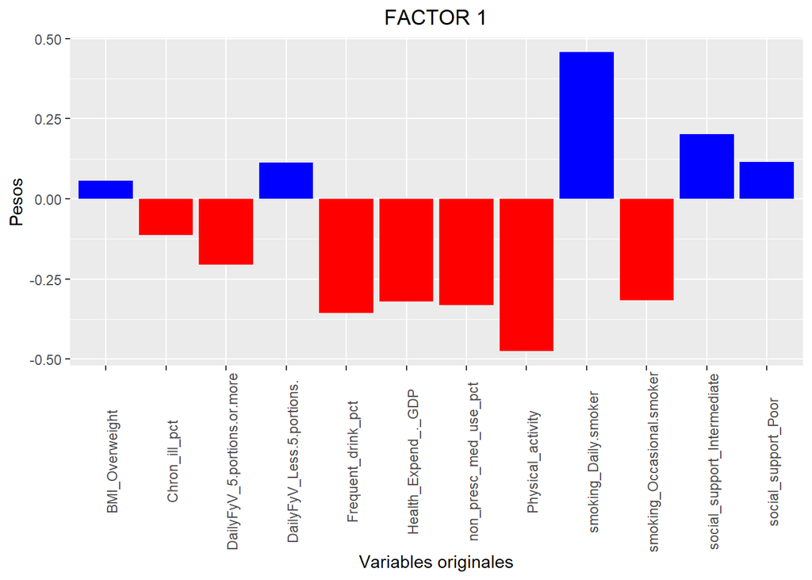

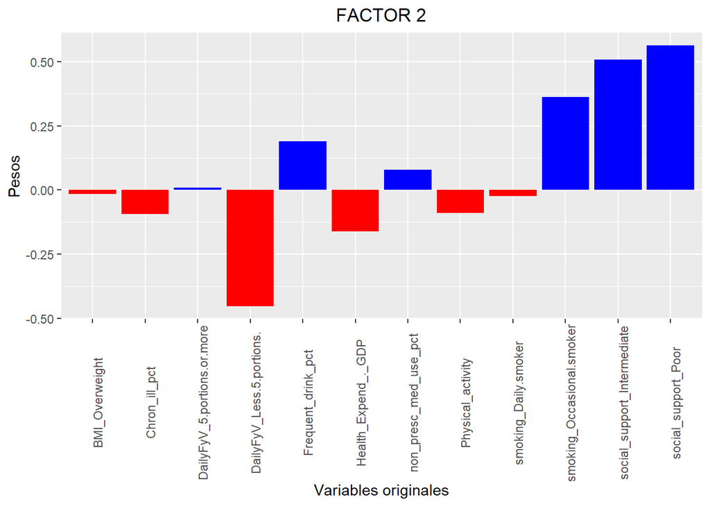

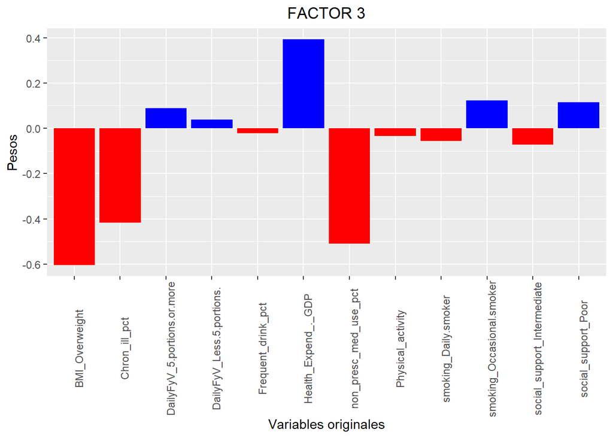

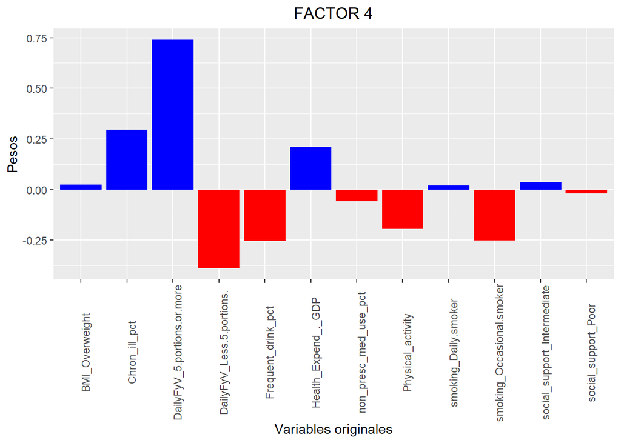

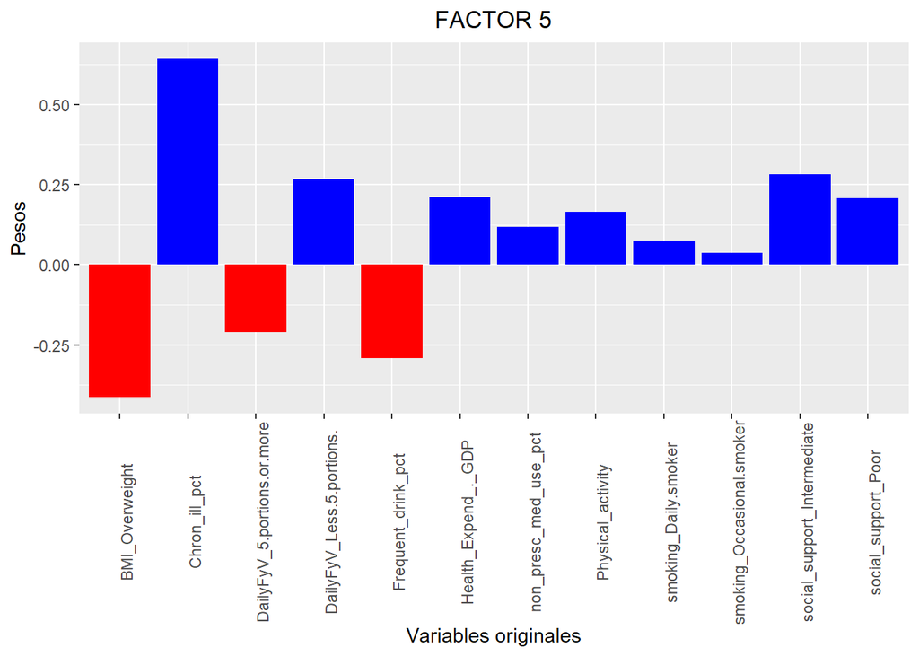

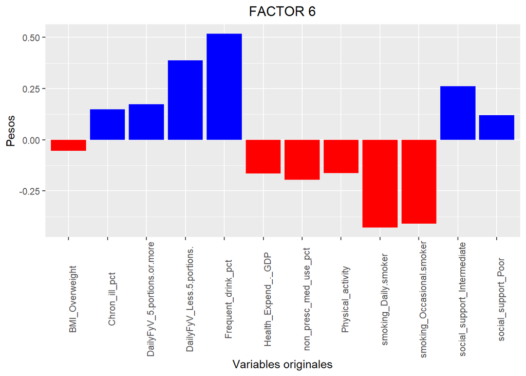

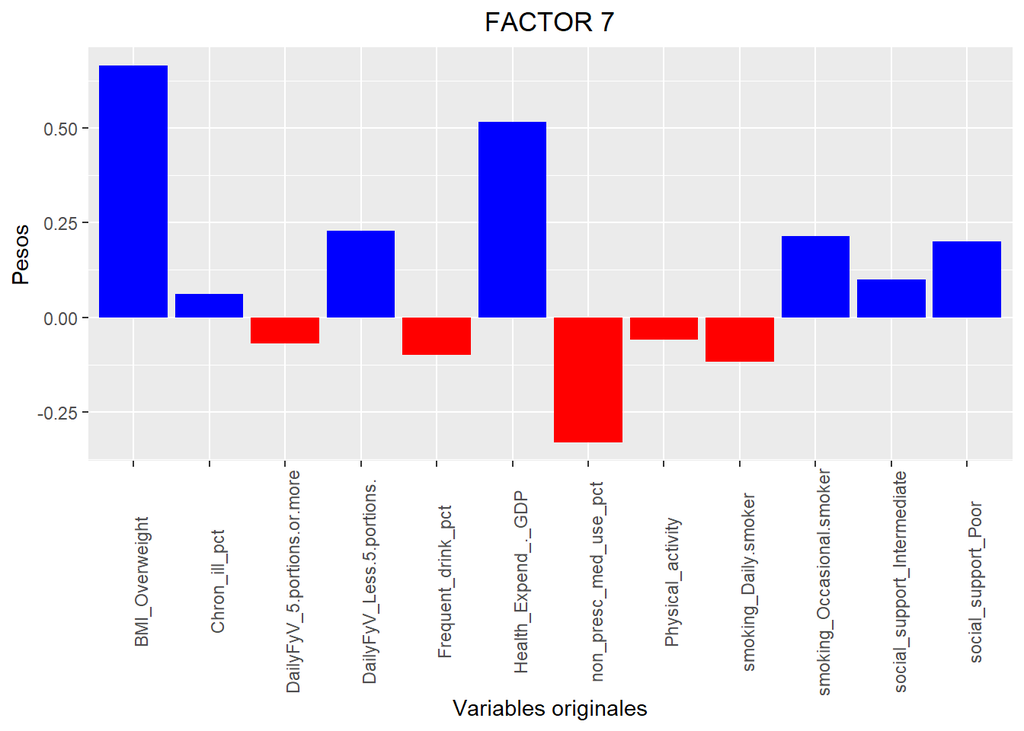

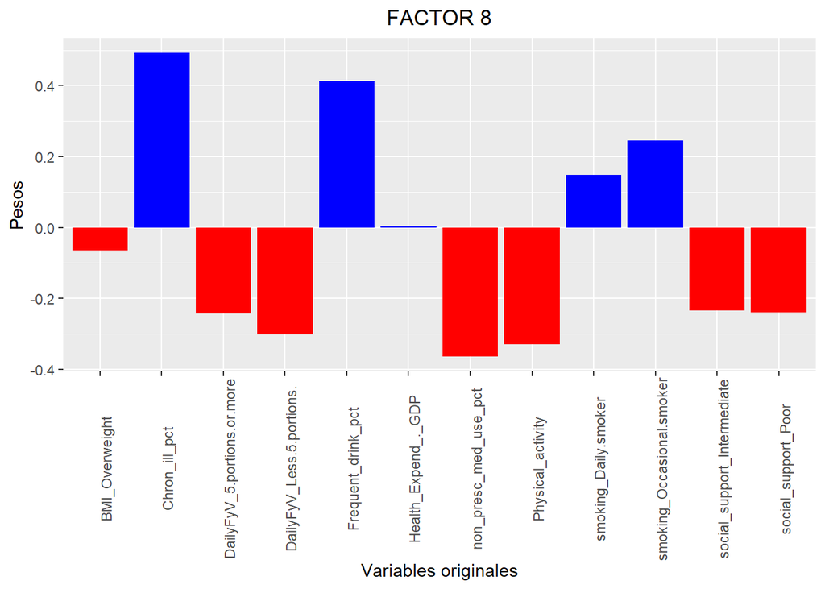

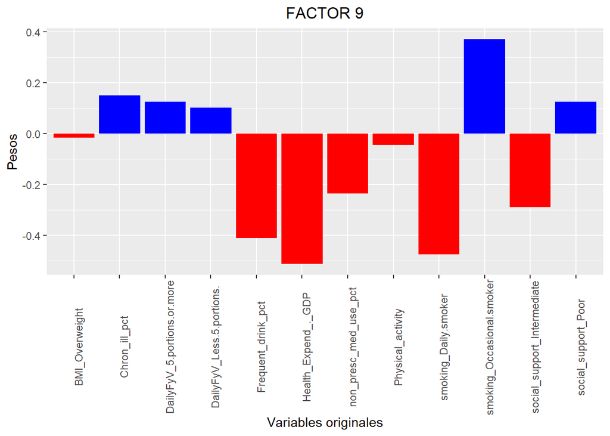

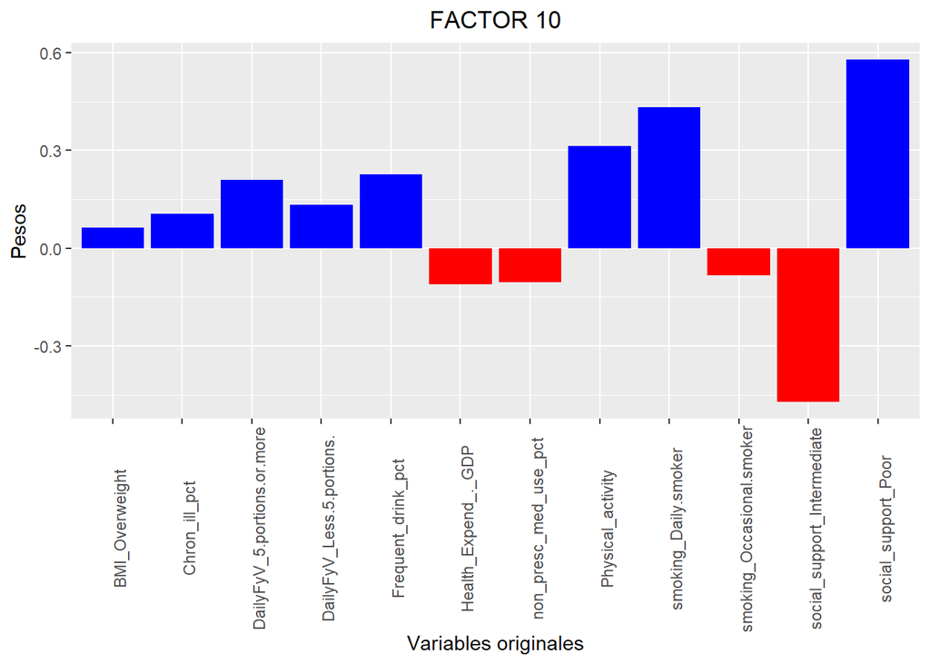

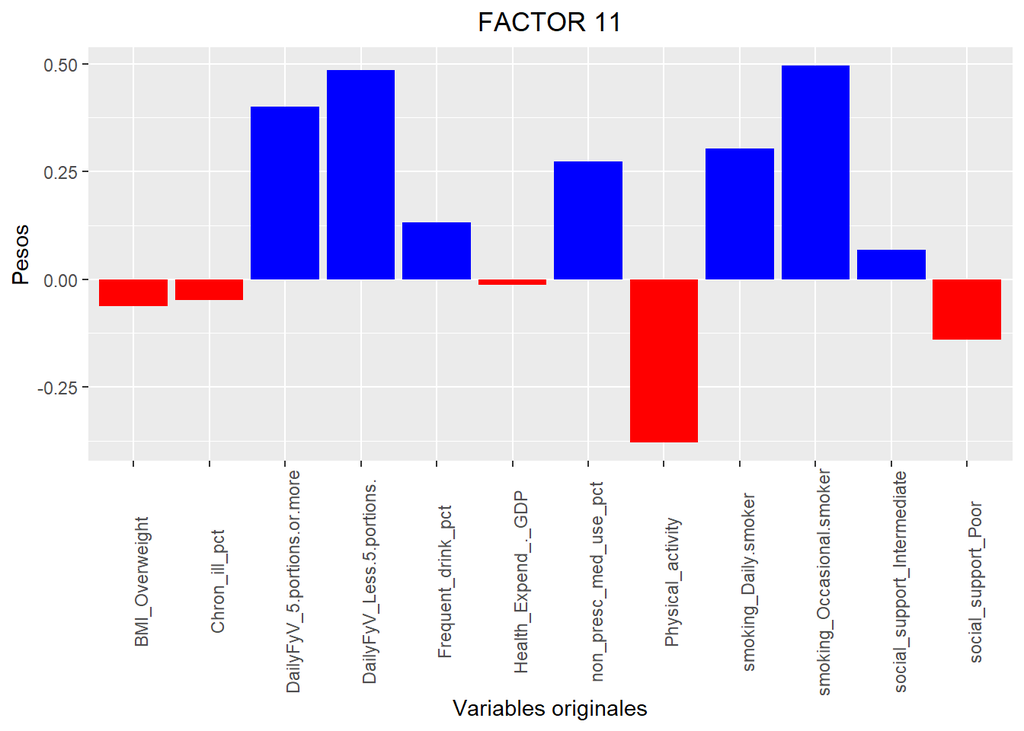

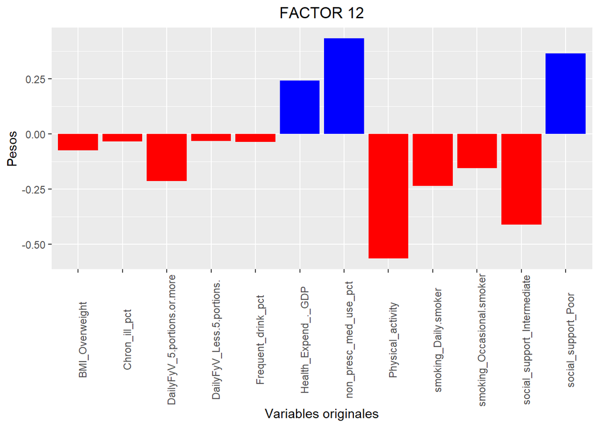

```r
# recuperamos los pesos

df.loadings <- data.frame(pca.pais$rotation[,1:12])

x.names <- row.names(df.loadings)



# grafica de los pesos de cada factor principal (PCA)

for(columna in 1:12){


  plot(ggplot(mapping = aes(x = x.names, y =df.loadings[,columna])) +
         geom_col(fill=ifelse(df.loadings[,columna]>=0,"blue","red")) + theme(axis.text.x = element_text(angle = 90)) +
    labs(x = "Variables originales", y = "Pesos")  +
    ggtitle(paste("FACTOR",columna)) +
      theme(plot.title = element_text(hjust = 0.5))

    )

}
```

De entre los factores encontramos de interes F1 y F3:

- **F1:**

Las variables con mayores aportaciones son con el signo positivo son “Smoking_Daily.smoker” y “social_support_intermediate”. Con el signo negativo por orden de mayor a menor peso “Physical activity”, “Frequent_Drink_pct”, practicamente iguales “Health_Expend”, “Smoking_Occasional.smoker” y “non_prescrib_med_use_pct”, y por último “DailyFyV_5.portions.or.more”

Para ambos signos se han despreciado las variables con valores inferiores o iguales a 0.125, por ser como valor prácticamente la cuarta parte de los valores máximos y por ser pocos en número respecto al resto, con lo cual su aportación no es comparable.

Para el signo positivo señalar que nos encontarmos con solo 2 variables a considerar. Aunque ninguna de ellas resultó significativa en la regresión logística la variable “social_support_intermediate” (existencia de soporte social pero insuficiente) da un claro tono negativo respecto del SPHpos. En cualquier caso hay que tener en cuenta que son en número (2) inferiores a las del signo negativo (6)

Valorando estas aportaciones en conjunto, teniendo en cuenta el significado de las variables, la orientación sobre la SPHpos de cada signo y el mayor número de variables y significancia de las mismas para el signo negativo, podemos concluir que el factor F1 resumido vendria a tener el significado de **“Soporte social insuficiente frente al Gasto sanitario y hábitos de vida considerados positivos”, con el carácter de cuanto más negativo mejor la autovaloración de salud (SPHpos)**

- **F3:**

En primer lugar para este factor las variables a considerar son menos ya que nos encontramos con bastantes de ellas con pesos ínfimos, inferiores o como mucho iguales a la cuarta parte de las 4 variables a considerar.

Con signo positivo y aportación única según lo comentado anteriormente nos encontramos con “Health_Expend”, variable significativa y de aporte positivo a la SPHpos. Con el signo negativo tenemos a “BMI_Overweight”, “Chron_ill_pct” y “non_prescrib_med_use_pct”, las dos primeras significativas y con aporte negativo (aporte grande en el caso de la enfermedad crónica) a la SPHpos, la tercera no significativa y neutra (sin poder observarse orientación en las distribuciones por SPHpos en el EDA).Podría esta tercera incluso verse como consecuencia de la condición de enfermedad crónica ya contemplada.

Valorando globalmente estas aportaciones, teniendo en cuenta el significado de las variables, la orientación sobre la SPHpos de cada signo, podemos concluir que el factor F3 resumido vendria a tener el significado de **“Gasto sanitario frente a mala condición física (sobrepeso, enfermedad crónica)”, con el carácter de cuanto más positivo mejor la autovaloración de salud (SPHpos)**

Destacar el **factor bivalente que tiene la variable “non_prescrib_med_use_pct”, que con peso a considerar actua a favor (signo negativo del factor) del SPHpos para F1 y en contra (signo negativo) para F3**

Como resumen:

- **F1: “Soporte social insuficiente frente al Gasto sanitario y hábitos de vida considerados positivos”. La valoración positiva del estado de salud (SPHpos) se corresponde con el signo negativo.**
- **F3: “Gasto sanitario frente a mala condición física (sobrepeso, enfermedad crónica)”. La valoración positiva del estado de salud (SPHpos) se corresponde con el signo positivo**
- **posible influencia en algún caso a vigilar del factor bivalente variable “non_prescrib_med_use_pct”, que actua a favor (signo negativo) de la valoración positiva de salud para F1 y en contra (signo negativo) para F3**

## 3.2 Clusterización a partir de los componentes principales comentados (F1,F3)

### Punto de partida, grafica (F1,F3) de los países.

Con el significado de cada uno comentado en el apartado anterior, echamos primero un vistazo a como quedaría la gráfica de los países tomando estos dos factores como coordenadas cartesianas.

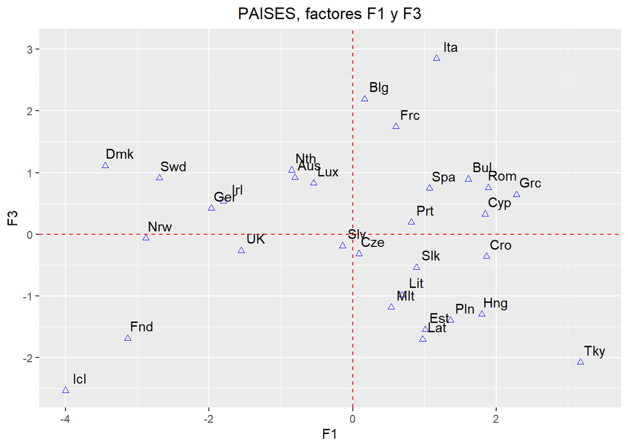

```r
# etiquetas países para la gráfica
abrev.pais <- c("Aus","Blg","Bul","Cro","Cyp","Cze","Dmk","Est","Fnd","Frc","Ger","Grc","Hng","Icl","Irl","Ita","Lat","Lit","Lux","Mlt","Nth","Nrw","Pln","Prt","Rom","Slk","Slv","Spa","Swd","Tky","UK")

# dataset con la información para la representación
dfHD.factoresPCA.expl <- data.frame(
  "GEO" = dfHD.pais.num$GEO,
  "abrev" = abrev.pais,
  "F1" = pca.pais$x[,1],
  "F3" = pca.pais$x[,3]
)


# grafica países
ggplot(data = dfHD.factoresPCA.expl, mapping = aes(x = F1, y = F3)) +
geom_point(color = "blue", shape=24) +
  geom_hline(yintercept = 0, color="red", linetype="dashed") +
  geom_vline(xintercept = 0, color="red", linetype="dashed") +
  geom_text(label=dfHD.factoresPCA.expl$abrev, nudge_x = 0.2, nudge_y = 0.2, check_overlap = F) +
  labs(title = "PAISES, factores F1 y F3") +
ylab("F3") +
xlab("F1") +
  theme(plot.title = element_text(hjust = 0.5))
```

Nos encontramos en primer lugar con 2 agrupaciones más separadas del resto, la formada solo por Turquia en la esquina inferior derecha y la formada por Islandia y Finlandia en la inferior izquierda. Con menos separación se observa también el grupo de 3 formado por Italia, Bélgica y Francia en la parte superior derecha.

Existe además una serie de puntos más separados en el cuadrante superior izquierda (con Reino Unido y Noruega cruzando el límite ligeramente, valor muy poco negativo de F3), destacando como muy cercanos entre sí a Holanda, Austria y Luxemburgo. El resto de este cuadrante son Dinamarca, Suecia Alemania e Irlanda.

Por último en la parte derecha junto con dos puntos en el centro se encuentran una serie de países. Esa agrupación se pudiera quizas dividir en 2 (superior e inferior) por el signo de F3. Serían en la superio España, Portugal, Grecia, Chipre, Rumanía y Bulgaria. En la inferior estarían Croacia, Eslovaquia, Estonia, Letonia, Lituania, Malta, Polonia y Hungría. En la parte central para terminar tenemos a Eslovenia y la República Checa.